# Examples

This document collates and annotates the examples from Grym.

```r
library(Grym)
```

## vonBertalanffyAL

The GYM uses the von Bertalanffy growth curve
$$L = L_{\infty} \left ( 1 - e^{-K (A-t_{0})} \right )$$
to map ages to lengths.

The `vonBertalanffyAL` function implments the von Bertalanffy growth curve as parameterized in the GYM

```r
age <- 2:8

## Convert age to length
len <- vonBertalanffyAL(A=age, t0=0.0667, K=0.5, Linf=500)
len
[1] 309.8225 384.6515 430.0376 457.5657 474.2623 484.3893 490.5316
```

and `vonBertalanffyLA` is the inverse mapping

```r
## Convert length to age
age <- vonBertalanffyLA(L=len, t0=0.0667, K=0.5, Linf=500)
age
[1] 2 3 4 5 6 7 8
```

#### Length at age

Define age classes and within year time steps

```r
## Daily time steps and 7 age classes
nsteps <- 365
Ages <- 2:8
Days <- seq(from=0, to=1, length=nsteps+1)
h <- 1/nsteps
```

Create a matrix of the age at each time step of each age class

```r
## Ages
ages <- outer(X=Days, Y=Ages, FUN="+")
```

Use a von Bertalanffy length at age relationship to create a matrix of the length at each time step of each age class

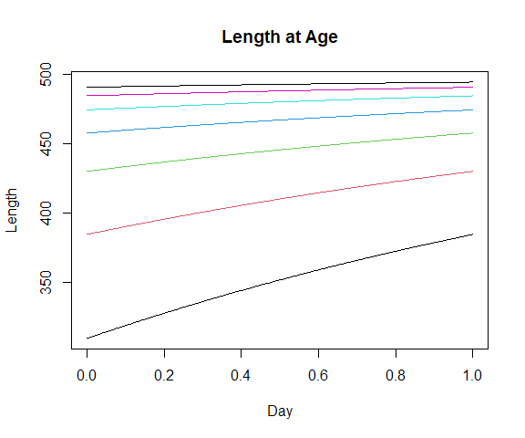

```r
## Age-length conversion
ls <- vonBertalanffyAL(A=ages, t0=0.0667, K=0.5, Linf=500)
matplot(x=Days, y=ls, type="l", lty=1, xlab="Day", ylab="Length", main="Length at Age")
```

The restricted model assumes that growth is restricted to some fraction of the year

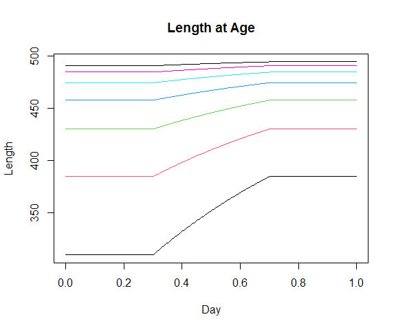

```r
## Age-length conversion - growth occurs in middle of the year
ls <- vonBertalanffyRAL(A=ages, t0=0.0667, K=0.5, Linf=500, f0=0.3, f1=0.7)
matplot(x=Days, y=ls, type="l", lty=1, xlab="Day", ylab="Length", main="Length at Age")
```

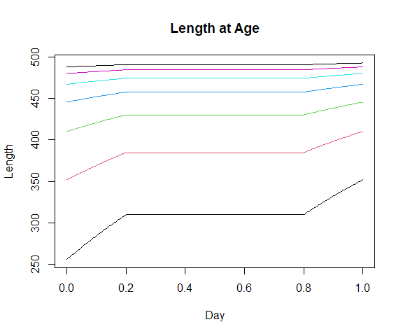

```r
## Age-length conversion - growth occurs across the year boundary
ls <- vonBertalanffyRAL(A=ages, t0=0.0667, K=0.5, Linf=500, f0=0.8, f1=1.2)
matplot(x=Days, y=ls, type="l", lty=1, xlab="Day", ylab="Length", main="Length at Age")
```

## powerLW

The GYM uses a simple power law model
$$W = a L^b$$
to map lengths to weights.

The `powerLW` function implements the power law model as parameterized in the GYM

```r
len <- seq(from=150, to=450, by=50)

## Convert length to weight
wgt <- powerLW(L=len, a=9.0E-10, b=3.32)
wgt
[1] 0.01509613 0.03923396 0.08230066 0.15075963 0.25150604 0.39181556 0.57930604
```

and `powerWL` is the inverse mapping

```r
## Convert weigth to length
len <- powerWL(W=wgt, a=9.0E-10, b=3.32)
len
[1] 150 200 250 300 350 400 450
```

#### Weight at age

Define age classes and within year time steps

```r
## Daily time steps and 7 age classes
nsteps <- 365
Ages <- 2:8
Days <- seq(from=0, to=1, length=nsteps+1)
h <- 1/nsteps
```

Create a matrix of the age at each time step of each age class

```r
## Ages
ages <- outer(X=Days, Y=Ages, FUN="+")
```

Use a von Bertalanffy length at age relationship to create a matrix of the length at each time step of each age class

```r
## Age-length conversion
ls <- vonBertalanffyAL(A=ages, t0=0.0667, K=0.5, Linf=500)
```

and a power law weight-length relationship to create a matrix of the weight at each time step of each age class

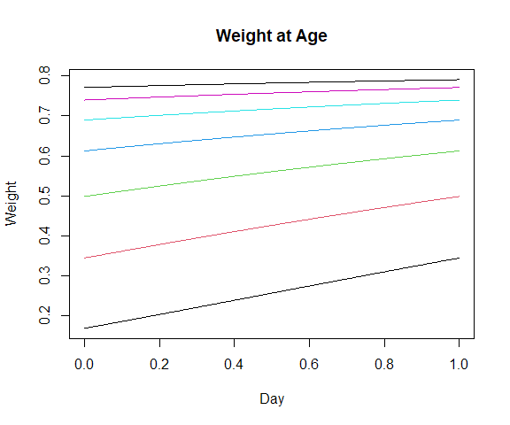

```r
## Length-weight conversion
ws <- powerLW(L=ls, a=9E-10, b=3.32)
matplot(x=Days, y=ws, type="l",lty=1,xlab="Day",ylab="Weight",main="Weight at Age")
```

## rampOgive

The GYM uses a simple ramp shaped ogive to model both maturity and fishing selectivity.

The `rampOgive` function implements a ramp ogive parameterized in terms of the mid-point and width of the ramp

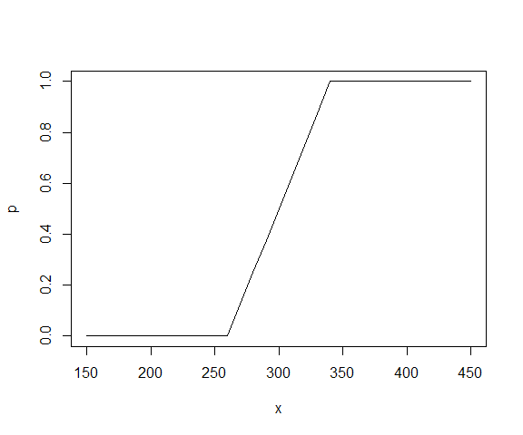

```r
x <- seq(from=150, to=450, by=10)
p <- rampOgive(x, x50=300, xrange=80)
plot(x=x, y=p, type="l")
```

## logisticOgive

Grym provides a logistic ogive to model both maturity or fishing selectivity.

The `logisticOgive` function implements a logistic ogive parameterized in terms of the 50th percentile, and the difference between the 95th and 50th percentiles

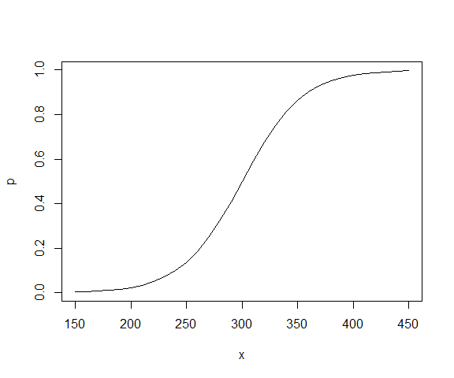

```r
x <- seq(from=150, to=450, by=10)
p <- logisticOgive(x, x50=300, d95=80)
plot(x=x, y=p, type="l")
```

## doubleNormalSelectivity

The `doubleNormalSelectivity` function implements a double Normal or “dome shaped” selectivity function.

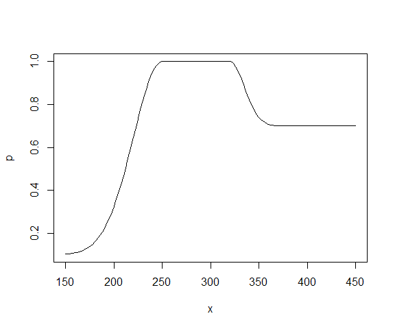

```r
x <- seq(from=150, to=450, by=2)
p <- doubleNormalSelectivity(x, x1=250, x2=320, s1=30, s2=15, y1=0.1, y2=0.7)
plot(x=x, y=p, type="l")
```

## trapz

The `trapz` function implements the composite trapezoidal rule for numerical quadrature, and `ctrapz` implements a “cumulative” trapezoidal rule.

Consider the definite integral
$$\int_{1}^{x} 2 x dx = x^2 - 1$$

```r
## The definite integral of 2*x from 1 to x is x^2-1
x <- 1:5
ctrapz(fs=2*x, h=1)
[1]  0  3  8 15 24
trapz(fs=2*x, h=1)
[1] 24
```

For a matrix argument, these functions operate column by column

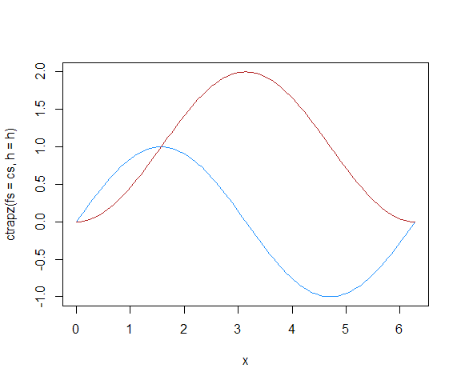

```r
## Integrate cos(x),  sin(x)
h <- 2*pi/100
x <- seq(from=0, to=2*pi, by=h)
cs <- cbind(cos(x), sin(x))
matplot(x=x, y=ctrapz(fs=cs, h=h), type="l", lty=1, col=c("dodgerblue", "firebrick"))
```

## meanTrapz

The `meanTrapz` computes averages over a time interval, but if the interval consists of a single point the value at that point is returned.

For an interval `trapzMean` computes averages with the trapezoidal rule

```r
## The average of 2*x from 1 to 5
x <- 1:5
trapzMeans(fs=2*x)
[1] 6
trapz(fs=2*x, h=1)/4
[1] 6
```

But if the interval is a single point, the value of the function at that point is returned.

```r
## For a single point return the function value
x <- 1
trapzMeans(fs=2*x)
[1] 2
```

For a matrix argument, these functions operate column by column

```r
## Average of cos(x), sin(x) from 0 to 2 pi
h <- 2*pi/100
x <- seq(from=0, to=2*pi, by=h)
cs <- cbind(cos(x), sin(x))
trapzMeans(fs=cs)
[1]  4.218847e-17 -1.241954e-18
```

## project

The `project` function projects abundance, biomass and yield by age class forward over one year when natural and fishing mortalities are known.

#### Setup

Define age classes and within year time steps

```r
## Daily time steps and 7 age classes
nsteps <- 365
Ages <- 2:8
Days <- seq(from=0, to=1, length=nsteps+1)
h <- 1/nsteps
```

Create matrices of age, length and weight for each time step and age class

```r
## Ages
ages <- outer(X=Days, Y=Ages, FUN="+")
## Age-length and length-weight conversions
ls <- vonBertalanffyAL(A=ages, t0=0.0667, K=0.5, Linf=500)
ws <- powerLW(L=ls, a=9E-10, b=3.32)
```

Define the normalized intra-annual natural mortality, its integral and the annual scaling

```r
## Constant intra-annual natural mortality
ms <- matrix(data=1, nrow=nsteps+1, ncol=length(x=Ages))
ms <- ms/mean(x=trapz(fs=ms, h=h))
Ms <- ctrapz(fs=ms, h=h)
Msf <- final(P=Ms)
M <- 0.1
```

```r
## Normalized within year distribution of fishing effort
fwy <- double(length=nsteps+1)
fwy[81:220] <- 1
fwy <- fwy/trapz(fs=fwy, h=h)
## Length based selectivity
ss <- rampOgive(x=ls, x50=420, xrange=30)
```

Define the normalized intra-annual fishing mortality, its integral and the annual scaling.

```r
## Intra-annual fishing mortality - effort by selectivity
fs <- fwy*ss
Fs <- ctrapz(fs=fs, h=h)
Fsf <- final(P=Fs)
F <- 0.2
```

#### Projection from equilibrium

Project forward one year from an equilibrium age structure.

Compute an intial age structure assuming constant mortalities and assuming no plus class

```r
## Deterministic initial age structure
N0 <- ageStructureD(MMsf=M*Msf, FFsf=F*Fsf)
N0
[1] 1.0000000 0.9048374 0.8040328 0.5956421 0.4412625 0.3268953 0.2421700
```

Project forward for a single year with known mortalities

```r
## Annual projection from N0
pr <- project(ws=ws, MMs=M*Ms, FFs=F*Fs, Ffs=F*fs, Nref=N0, yield=2)
```

Examine the final abundance and total yield

```r
## Final abundance
pr$N[nsteps+1,]
[1] 0.9048374 0.8040328 0.5956421 0.4412625 0.3268953 0.2421700 0.1794040
## Total annual yield
sum(pr$Y[nsteps+1,])
[1] 0.2811238
```

Plot the initial age structure and resulting profiles of abundance, biomass and yield by age class

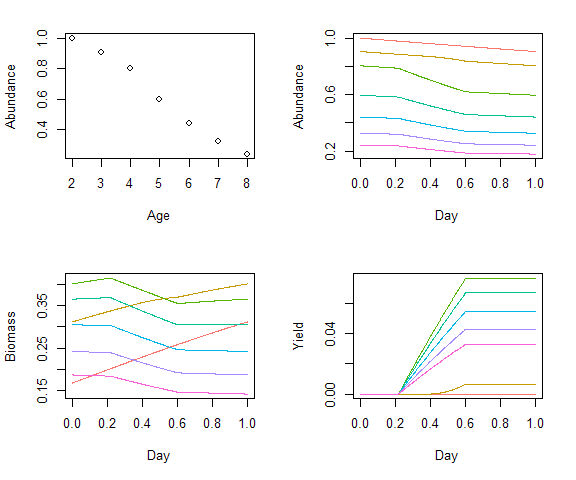

```r
## Plot initial abundance, projected abundance, biomass and yield
opar <- par(mfrow=c(2,2), mar=c(5,4,2,2)+0.1)
pal <- hcl(h=seq(from=15, to=375, length=8)[1:7], l=65, c=100)
plot(x=Ages, y=N0, xlab="Age", ylab="Abundance")
matplot(x=Days, y=pr$N, xlab="Day", ylab="Abundance", type="l", lty=1, col=pal)
matplot(x=Days, y=pr$B, xlab="Day", ylab="Biomass", type="l", lty=1, col=pal)
matplot(x=Days, y=pr$Y, xlab="Day", ylab="Yield", type="l", lty=1, col=pal)
par(opar)
```

#### Projection from survey

Project forward one year, matching given average relative abundance and total biomass over a set of reference time steps obtained from a survey

```r
## Annual projection given relative abundance and total
## biomass estimated from a five day mid-year survey (days 150 to 154)
Nsurvey <- c(1.0,0.67,0.46,0.33,0.25,0.18,0.13)
Bsurvey <- 15000
pr <- project(ws=ws, MMs=M*Ms, FFs=F*Fs, Ffs=F*fs, Nref=Nsurvey,
              nref=151:155, Bref=Bsurvey, yield=2)
```

Examine the total annual yield

```r
## Total annual yield
sum(pr$Y[nsteps+1,])
[1] 1954.908
```

Plot the initial age structure and resulting profiles of abundance, biomass and yield by age class

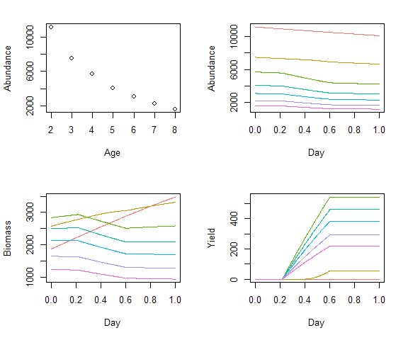

```r
## Plot initial abundance, projected abundance, biomass and yield
opar <- par(mfrow=c(2,2), mar=c(5,4,2,2)+0.1)
pal <- hcl(h=seq(from=15, to=375, length=8)[1:7],l=65,c=100)
plot(x=Ages, y=pr$N[1,], xlab="Age", ylab="Abundance")
matplot(x=Days, y=pr$N, xlab="Day", ylab="Abundance", type="l" ,lty=1, col=pal)
matplot(x=Days, y=pr$B, xlab="Day", ylab="Biomass", type="l", lty=1, col=pal)
matplot(x=Days, y=pr$Y, xlab="Day", ylab="Yield", type="l", lty=1, col=pal)
par(opar)
```

#### Multi-year projection

Project forward 10 years from a virgin stock assuming constant fishing mortality, collating annual abundance, biomass and yield.

Create matrices to store annual projections

```r
## Ten year projection from virgin stock collating final annual
## abundance, biomass and yield
Years <- 1:10
Nf <- Bf <- Yf <- matrix(data=NA, nrow=length(Years), ncol= length(Ages))
```

Compute an equilibrium age structure assuming constant natural mortality and no fishing, assuming no plus class and 8000 recruits per year.

```r
## Deterministic initial age structure assuming no fishing and 8000
## new recruits each year
N0 <- ageStructureD(MMsf=M*Msf, R=8000)
```

For each year, project forward from the initial abundance assuming constant fishing mortality, update the the initial abundance for the next projection assuming 8000 new recruits, and record the final abundance, biomass and yield from the projection

```r
## Project forward with constant fishing mortality
for(k in 1:nrow(x=Nf)) {
  pr <- project(ws=ws, MMs=M*Ms, FFs=F*Fs, Ffs=F*fs, Nref=N0, yield=1)
  N0 <- advance(N=pr$N, R=8000)
  Nf[k,] <- final(P=pr$N)
  Bf[k,] <- final(P=pr$B)
  Yf[k,] <- pr$Y
}
```

Plot final abundance, biomass and yield for each year by age class

```r
## Plot annual abundance, biomass and yield
opar <- par(mfrow=c(2,2), mar=c(5,4,2,2)+0.1)
pal <- hcl(h=seq(from=15, to=375, length=8)[1:7], l=65, c=100)
matplot(x=Years, y=Nf, xlab="Year", ylab="Abundance", type="l", lty=1, col=pal)
matplot(x=Years, y=Bf, xlab="Year", ylab="Biomass", type="l", lty=1, col=pal)
matplot(x=Years, y=Yf, xlab="Year", ylab="Yield", type="l", lty=1, col=pal)
par(opar)
```

[output not shown]

## projectC

The `projectC` function projects abundance, biomass and yield by age class forward over one year when natural mortality and total annual yield are known.

#### Setup

Define age classes and within year time steps

```r
## Daily time steps and 7 age classes
nsteps <- 365
Ages <- 2:8
Days <- seq(from=0, to=1, length=nsteps+1)
h <- 1/nsteps
```

Create matrices of age, length and weight for each time step and age class

```r
## Ages
ages <- outer(X=Days, Y=Ages, FUN="+")
## Age-length and length-weight conversions
ls <- vonBertalanffyAL(A=ages, t0=0.0667, K=0.5, Linf=500)
ws <- powerLW(L=ls, a=9E-10, b=3.32)
```

Define the normalized intra-annual natural mortality, its integral and the annual scaling

```r
## Constant intra-annual natural mortality
ms <- matrix(data=1, nrow=nsteps+1, ncol=length(x=Ages))
ms <- ms/mean(x=trapz(fs=ms, h=h))
Ms <- ctrapz(fs=ms, h=h)
Msf <- final(P=Ms)
M <- 0.1
```

```r
## Normalized within year distribution of fishing effort
fwy <- double(length=nsteps+1)
fwy[81:220] <- 1
fwy <- fwy/trapz(fs=fwy, h=h)
## Length based selectivity
ss <- rampOgive(x=ls, x50=420, xrange=30)
```

Define the normalized intra-annual fishing mortality, its integral and the annual scaling.

```r
## Intra-annual fishing mortality - effort by selectivity
fs <- fwy*ss
Fs <- ctrapz(fs=fs, h=h)
Fsf <- final(P=Fs)
F <- 0.2
```

#### Projection from equilibrium

Project forward one year from an equilibrium age structure.

Compute an intial age structure assuming constant mortalities and assuming no plus class

```r
## Deterministic initial age structure
N0 <- ageStructureD(MMsf=M*Msf, FFsf=F*Fsf)
N0
[1] 1.0000000 0.9048374 0.8040328 0.5956421 0.4412625 0.3268953 0.2421700
```

Project forward for a single year, selecting the annual scaling of fishing mortality to reproduce the known catch

```r
## Annual projection from N0
pr <- projectC(ws=ws, MMs=M*Ms, Fs=Fs, fs=fs, Catch=0.2811238, Nref=N0, yield=2)
```

This determines the fishing mortality required to reproduce the target yield

```r
## Fishing mortality and total annual yield
pr$F
[1] 0.2
sum(pr$Y[nsteps+1,])
[1] 0.2811238
```

Plot the initial age structure and resulting profiles of abundance, biomass and yield by age class

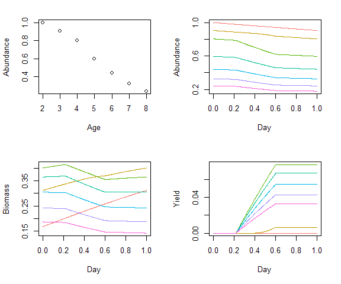

```r
## Plot initial abundance, projected abundance, biomass and yield
opar <- par(mfrow=c(2,2), mar=c(5,4,2,2)+0.1)
pal <- hcl(h=seq(from=15, to=375, length=8)[1:7], l=65, c=100)
plot(x=Ages, y=N0, xlab="Age", ylab="Abundance")
matplot(x=Days, y=pr$N, xlab="Day", ylab="Abundance", type="l", lty=1, col=pal)
matplot(x=Days, y=pr$B, xlab="Day", ylab="Biomass", type="l", lty=1, col=pal)
matplot(x=Days, y=pr$Y, xlab="Day", ylab="Yield", type="l", lty=1, col=pal)
par(opar)
```

#### Projection from survey

Project forward one year, matching given average relative abundance and total biomass over a set of reference time steps obtained from a survey

```r
## Annual projection given relative abundance and total
## biomass estimated from a five day mid-year survey (days 150 to 154)
Nsurvey <- c(1.0, 0.67, 0.46, 0.33, 0.25, 0.18, 0.13)
Bsurvey <- 15000
pr <- projectC(ws=ws, MMs=M*Ms, Fs=Fs, fs=fs, Catch=1954.908, Nref=Nsurvey,
               nref=151:155, Bref=Bsurvey, yield=2)
```

This determines the fishing mortality required to reproduce the target yield

```r
## Fishing mortality and total annual yield
pr$F
[1] 0.2
sum(pr$Y[nsteps+1,])
[1] 1954.908
```

Plot the initial age structure and resulting profiles of abundance, biomass and yield by age class

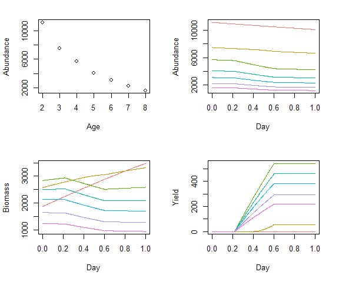

```r
## Plot initial abundance, projected abundance, biomass and yield
opar <- par(mfrow=c(2,2), mar=c(5,4,2,2)+0.1)
pal <- hcl(h=seq(from=15, to=375, length=8)[1:7], l=65, c=100)
plot(x=Ages, y=pr$N[1,], xlab="Age", ylab="Abundance")
matplot(x=Days, y=pr$N, xlab="Day", ylab="Abundance", type="l", lty=1, col=pal)
matplot(x=Days, y=pr$B, xlab="Day", ylab="Biomass", type="l", lty=1, col=pal)
matplot(x=Days, y=pr$Y, xlab="Day", ylab="Yield", type="l", lty=1, col=pal)
par(opar)
```

#### Unattainable target

If the target catch cannot be recovered without exceeding `Fmax`, the projection is performed with `F` capped at `Fmax`

```r
## Unattainable target catch - F is capped at Fmax
pr <- projectC(ws=ws, MMs=M*Ms, Fs=Fs, fs=fs, Catch=2, Nref=N0, yield=2, Fmax=2.5)
```

the yield does not match the target

```r
## Yield does not match target
sum(pr$Y[nsteps+1,])
[1] 1.463323
pr$F==2.5
[1] TRUE
```

#### Multi-year projection

Project forward 10 years from a virgin stock assuming constant catch, collating annual abundance, biomass and yield.

Create matrices to store annual projections

```r
## Ten year projection from virgin stock collating final annual
## abundance, biomass and yield
Years <- 1:10
Nf <- Bf <- Yf <- matrix(data=NA, nrow=length(x=Years), ncol=length(x=Ages))
```

Compute an equilibrium age structure assuming constant natural mortality and no fishing, assuming no plus class and 8000 recruits per year.

```r
## Deterministic initial age structure assuming no fishing and 8000
## new recruits each year
N0 <- ageStructureD(MMsf=M*Msf, R=8000)
```

For each year, project forward from the initial abundance assuming constant catch, update the the initial abundance for the next projection assuming 8000 new recruits, and record the final abundance, biomass and yield from the projection

```r
## Project forward with constant catch
for(k in 1:nrow(x=Nf)) {
  pr <- projectC(ws=ws, MMs=M*Ms, Fs=Fs, fs=fs, Catch=4000, Nref=N0, yield=1)
  N0 <- advance(N=pr$N, R=8000)
  Nf[k,] <- final(P=pr$N)
  Bf[k,] <- final(P=pr$B)
  Yf[k,] <- pr$Y
}
```

Plot final abundance, biomass and yield for each year by age class

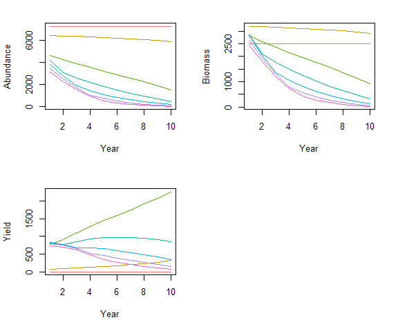

```r
## Plot annual abundance, biomass and yield
opar <- par(mfrow=c(2, 2), mar=c(5, 4, 2, 2)+0.1)
pal <- hcl(h=seq(from=15, to=375, length=8)[1:7], l=65, c=100)
matplot(x=Years, y=Nf, xlab="Year", ylab="Abundance", type="l", lty=1, col=pal)
matplot(x=Years, y=Bf, xlab="Year", ylab="Biomass", type="l", lty=1, col=pal)
matplot(x=Years, y=Yf, xlab="Year", ylab="Yield", type="l", lty=1, col=pal)
par(opar)
```

## advance

The `advance` function constructs the initial abundance for the next annual projection given the projected abundances for the current year. Essentially, `advance` advances the final abundance of each cohort by an age class filling the first age class with recruits. If the last age class is a “plus” class, the surviving individuals of the plus class are retained when the classes advance, otherwise these individuals are lost to the population.

#### Setup

Define age classes and within year time steps

```r
## Daily time steps and 7 age classes
nsteps <- 365
Ages <- 2:8
Days <- seq(from=0,to=1,length=nsteps+1)
h <- 1/nsteps
```

Create matrices of age, length and weight for each time step and age class

```r
## Ages
ages <- outer(X=Days, Y=Ages, FUN="+")
## Age-length and length-weight conversions
ls <- vonBertalanffyAL(A=ages, t0=0.0667, K=0.5, Linf=500)
ws <- powerLW(L=ls, a=9E-10, b=3.32)
```

Define the intra-annual natural mortality, its integral and the annual scaling

```r
## Constant intra-annual natural mortality
ms <- matrix(data=1, nrow=nsteps+1, ncol=length(x=Ages))
ms <- ms/mean(x=trapz(fs=ms, h=h))
Ms <- ctrapz(fs=ms, h=h)
Msf <- final(P=Ms)
M <- 0.1
```

```r
## Define fishing mortalities - mid-year fishing with length based selectivity
fs <- double(length=nsteps+1)
fs[81:220] <- 1
fs <- fs/trapz(fs=fs, h=h)
fs <- fs*rampOgive(x=ls, x50=420, xrange=30)
Fs <- ctrapz(fs=fs, h=h)
Fsf <- final(P=Fs)
F <- 0.2
```

Compute an intial age structure assuming constant mortalities

```r
## Deterministic initial age structure
N0 <- ageStructureD(MMsf=M*Msf, FFsf=F*Fsf)
N0
[1] 1.0000000 0.9048374 0.8040328 0.5956421 0.4412625 0.3268953 0.2421700
```

Project forward for a single year with known mortalities

```r
## Annual projection from N0
pr <- project(ws=ws, MMs=M*Ms, FFs=F*Fs, Ffs=F*fs, Nref=N0)
```

The projected final abundance is

```r
## Final abundance
pr$N[nsteps+1,]
[1] 0.9048374 0.8040328 0.5956421 0.4412625 0.3268953 0.2421700 0.1794040
```

#### Advance

Advance the final cohort numbers by one age class to form the initial numbers for the next projection. If the final age class is not a plus group individuals in the final age class are discarded in the advancement

```r
## Initial abundance for next projection assuming no plus group
advance(N=pr$N, R=1, plus=FALSE)
[1] 1.0000000 0.9048374 0.8040328 0.5956421 0.4412625 0.3268953 0.2421700
```

If the final age class is a plus group the individuals in the final age class are retained

```r
## Initial abundance for next projection assuming plus group
advance(N=pr$N, R=1, plus=TRUE)
[1] 1.0000000 0.9048374 0.8040328 0.5956421 0.4412625 0.3268953 0.4215740
```

#### Project without plus class

Project forward 10 years from a virgin stock assuming constant fishing mortality, collating annual abundance, biomass and yield, assuming the final class is not a plus class.

Create matrices to store annual projections

```r
## Ten year projection from virgin stock collating final annual
## abundance, biomass and yield
Years <- 1:10
Nf <- Bf <- Yf <- matrix(data=NA, nrow=length(x=Years), ncol=length(x=Ages)) #produce identical matrices Nf, Bf and Yf
```

Compute an equilibrium age structure assuming constant natural mortality and no fishing, assuming no plus class and 8000 recruits per year.

```r
## Deterministic initial age structure assuming no fishing and 8000
## new recruits each year
N0 <- ageStructureD(MMsf=M*Msf, R=8000)
```

For each year, project forward from the initial abundance assuming constant fishing mortality, update the the initial abundance for the next projection assuming 8000 new recruits, and record the final abundance, biomass and yield from the projection

```r
## Project forward with constant fishing mortality
for(k in 1:nrow(x=Nf)) {
  pr <- project(ws=ws, MMs=M*Ms, FFs=F*Fs, Ffs=F*fs, Nref=N0, yield=1)
  N0 <- advance(N=pr$N, R=8000)
  Nf[k,] <- final(P=pr$N)
  Bf[k,] <- final(P=pr$B)
  Yf[k,] <- pr$Y
}
```

Plot final abundance, biomass and yield for each year by age class

```r
## Plot annual abundance, biomass and yield
opar <- par(mfrow=c(2,2),mar=c(5,4,2,2)+0.1)
pal <- hcl(h=seq(from=15, to=375, length=8)[1:7], l=65, c=100)
matplot(x=Years, y=Nf, xlab="Year", ylab="Abundance", type="l", lty=1, col=pal)
matplot(x=Years, y=Bf, xlab="Year", ylab="Biomass", type="l", lty=1, col=pal)
matplot(x=Years, y=Yf, xlab="Year", ylab="Yield", type="l", lty=1, col=pal)
par(opar)
```

[output not shown]

#### Project with plus class

Project forward 10 years from a virgin stock assuming constant fishing mortality, collating annual abundance, biomass and yield, assuming the final class is a plus class.

Create matrices to store annual projections

```r
## Ten year projection from virgin stock collating final annual
## abundance, biomass and yield
Years <- 1:10
Nf <- Bf <- Yf <- matrix(data=NA, nrow=length(x=Years), ncol=length(x=Ages))
```

Compute an equilibrium age structure assuming constant natural mortality and no fishing with 8000 recruits per year. Treat the last class as a plus group assuming an additional 50 age classes are aggregated into the plus class

```r
## Deterministic initial age structure assuming no fishing, 8000
## new recruits each year and a plus class
N0 <- ageStructureD(MMsf=M*Msf, R=8000, plus=50)
```

For each year, project forward from the initial abundance assuming constant fishing mortality, update the the initial abundance for the next projection assuming 8000 new recruits and assuming the last class is a plus class, and record the final abundance, biomass and yield from the projection

```r
## Project forward with constant fishing mortality assuming plus class
for(k in 1:nrow(x=Nf)) {
  pr <- project(ws=ws, MMs=M*Ms, FFs=F*Fs, Ffs=F*fs, Nref=N0, yield=1)
  N0 <- advance(N=pr$N, R=8000, plus=TRUE)
  Nf[k,] <- final(P=pr$N)
  Bf[k,] <- final(P=pr$B)
  Yf[k,] <- pr$Y
}
```

Plot final abundance, biomass and yield for each year by age class

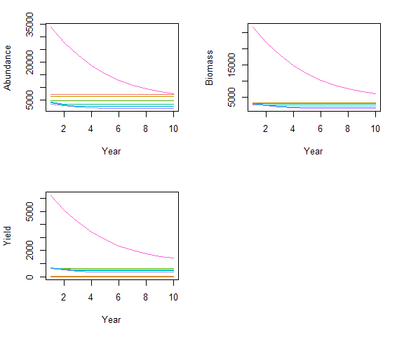

```r
## Plot annual abundance, biomass and yield
opar <- par(mfrow=c(2,2), mar=c(5,4,2,2)+0.1)
pal <- hcl(h=seq(from=15, to=375, length=8)[1:7], l=65, c=100)
matplot(x=Years, y=Nf, xlab="Year", ylab="Abundance", type="l", lty=1, col=pal)
matplot(x=Years, y=Bf, xlab="Year", ylab="Biomass", type="l", lty=1, col=pal)
matplot(x=Years, y=Yf, xlab="Year", ylab="Yield", type="l", lty=1, col=pal)
par(opar)
```

## rescaleProjection

The `rescaleProjection` function rescales an existing projection to reproduce a prescribed reference abundance or biomass.

Define age classes and within year time steps

```r
## Daily time steps and 7 age classes
nsteps <- 365
Ages <- 2:8
Days <- seq(from=0, to=1, length=nsteps+1)
h <- 1/nsteps
```

Create matrices of age, length and weight for each time step and age class

```r
## Ages
ages <- outer(X=Days, Y=Ages, FUN="+")
## Age-length and length-weight conversions
ls <- vonBertalanffyAL(A=ages, t0=0.0667, K=0.5, Linf=500)
ws <- powerLW(L=ls, a=9E-10, b=3.32)
```

Define the normalized intra-annual natural mortality, its integral and the annual scaling

```r
## Constant intra-annual natural mortality
ms <- matrix(data=1, nrow=nsteps+1, ncol=length(x=Ages))
ms <- ms/mean(x=trapz(fs=ms, h=h))
Ms <- ctrapz(fs=ms, h=h)
Msf <- final(P=Ms)
M <- 0.1
```

```r
## Normalized within year distribution of fishing effort
fwy <- double(length=nsteps+1)
fwy[81:220] <- 1
fwy <- fwy/trapz(fs=fwy, h=h)
## Length based selectivity
ss <- rampOgive(x=ls, x50=420, xrange=30)
```

Define the normalized intra-annual fishing mortality, its integral and the annual scaling.

```r
## Intra-annual fishing mortality - effort by selectivity
fs <- fwy*ss
Fs <- ctrapz(fs=fs, h=h)
Fsf <- final(P=Fs)
F <- 0.2
```

Project forward 10 years from a virgin stock assuming constant fishing mortality, collating annual abundance, biomass and yield.

Create matrices to store annual projections

```r
## Ten year projection from virgin stock collating final annual
## abundance,  biomass and yield
Years <- 1:10
Nf <- Bf <- Yf <- matrix(data=NA, nrow=length(x=Years), ncol=length(x=Ages))
```

Compute an equilibrium age structure assuming constant natural mortality and no fishing, assuming no plus class and 8000 recruits per year.

```r
## Deterministic initial age structure assuming no fishing
N0 <- ageStructureD(MMsf=M*Msf, R=8000)
```

For the first year, project forward from the initial abundance assuming constant fishing mortality, update the the initial abundance for the next projection assuming 8000 new recruits, and record the final abundance, biomass and yield from the projection

```r
## Project first year
pr <- project(ws=ws, MMs=M*Ms, FFs=F*Fs, Ffs=F*fs, Nref=N0, yield=1)
N0 <- advance(N=pr$N, R=8000)
Nf[1, ] <- final(P=pr$N)
Bf[1, ] <- final(P=pr$B)
Yf[1, ] <- pr$Y
```

As the mortalities are constant from year to year, the projections for the subsequent years can be computed by rescaling the initial projection

```r
## Compute projections for subsequent years by rescaling
for(k in 2:nrow(Nf)) {
  pr <- rescaleProjection(pr=pr, Nref=N0)
  N0 <- advance(N=pr$N, R=8000)
  Nf[k, ] <- final(P=pr$N)
  Bf[k, ] <- final(P=pr$B)
  Yf[k, ] <- pr$Y
}
```

Plot final abundance, biomass and yield for each year by age class

```r
## Plot annual abundance,  biomass and yield
opar <- par(mfrow=c(2, 2), mar=c(5, 4, 2, 2)+0.1)
pal <- hcl(h=seq(from=15, to=375, length=8)[1:7], l=65, c=100)
matplot(x=Years, y=Nf, xlab="Year", ylab="Abundance", type="l", lty=1, col=pal)
matplot(x=Years, y=Bf, xlab="Year", ylab="Biomass", type="l", lty=1, col=pal)
matplot(x=Years, y=Yf, xlab="Year", ylab="Yield", type="l", lty=1, col=pal)
par(opar)
```

[output not shown]

## ageStructureD

The `ageStructureD` function computes the equilibrium age structure of the population assuming the recruitment and the annual scalings of natural and fishing mortality are constant

#### Setup

Define age classes and within year time steps

```r
## Daily time steps and 7 age classes
nsteps <- 365
Ages <- 2:8
Days <- seq(from=0, to=1, length=nsteps+1)
h <- 1/nsteps
```

Create matrices of age, length and weight for each time step and age class

```r
## Ages
ages <- outer(X=Days, Y=Ages, FUN="+")
## Age-length and length-weight conversions
ls <- vonBertalanffyAL(A=ages, t0=0.0667, K=0.5, Linf=500)
ws <- powerLW(L=ls, a=9E-10, b=3.32)
```

Define the intra-annual natural mortality, its integral and the annual scaling

```r
## Constant intra-annual natural mortality
ms <- matrix(data=1, nrow=nsteps+1, ncol=length(Ages))
ms <- ms/mean(x=trapz(fs=ms, h=h))
Ms <- ctrapz(fs=ms, h=h)
Msf <- final(P=Ms)
M <- 0.2
```

#### Age structure

Compute and initial age structure assuming no fishing and no plus group

```r
## Deterministic initial age structure assuming no fishing and no plus
## group
N0 <- ageStructureD(MMsf=M*Msf)
N0
[1] 1.0000000 0.8187308 0.6703200 0.5488116 0.4493290 0.3678794 0.3011942
```

Projecting forward with the same mortality used to compute the equilibrium age structure should leave the abundances stable

```r
## Annual projection from N0
pr <- project(ws=ws, MMs=M*Ms,Nref=N0)
## Initial and final abundance
pr$N[c(1,nsteps+1),]
          [,1]      [,2]      [,3]      [,4]      [,5]      [,6]      [,7]
[1,] 1.0000000 0.8187308 0.6703200 0.5488116 0.4493290 0.3678794 0.3011942
[2,] 0.8187308 0.6703200 0.5488116 0.4493290 0.3678794 0.3011942 0.2465970
```

The deterministic age structure should match the stochastic age structure for constant recruitment and mortalities. If the last class is not a plus class

```r
## Deterministic initial age structure with no plus class
ageStructureD(MMsf=M*Msf)
[1] 1.0000000 0.8187308 0.6703200 0.5488116 0.4493290 0.3678794 0.3011942
## Stochastic initial age structure with constant recruitment
ageStructureS(R=rep(1,20), Msf=Msf, M=M)
[1] 1.0000000 0.8187308 0.6703200 0.5488116 0.4493290 0.3678794 0.3011942
```

```r
## Deterministic initial age structure assuming the plus class
## aggregates 50 additional age classes
ageStructureD(MMsf=M*Msf, plus=20)
[1] 1.0000000 0.8187308 0.6703200 0.5488116 0.4493290 0.3678794 1.6366683
## Stochastic initial age structure with constant recruitment with
## plus class
ageStructureS(R=rep(1,7+20), Msf=Msf, M=M, plus=TRUE)
[1] 1.0000000 0.8187308 0.6703200 0.5488116 0.4493290 0.3678794 1.6366683
```

For the deterministic computation, the plus class can contain an infinite number of additional age classes

```r
## Deterministic initial age structure assuming no upper limit on age
ageStructureD(MMsf=M*Msf, plus=Inf)
[1] 1.0000000 0.8187308 0.6703200 0.5488116 0.4493290 0.3678794 1.6615847
```

#### Scaling

By default the scaling of the abundances are determined by the level of recruitment

```r
## Scale to recruitment
N0 <- ageStructureD(MMsf=M*Msf, R=8000)
N0
[1] 8000.000 6549.846 5362.560 4390.493 3594.632 2943.036 2409.554
```

Alternately, the age structure can used as a relative abundances and scaled to a mid-year survey biomass with `project`

```r
## Scale age structure to biomass estimated from a five day mid-year
## survey (days 150 to 154)
Bsurvey <- 15000
N0 <- ageStructureD(MMsf=M*Msf)
pr <- project(ws=ws, MMs=M*Ms, FFs=0, Ffs=0, Nref=N0, nref=1, Bref=Bsurvey, bref=151:155)
N0 <- initial(P=pr$N)
N0
[1] 7627.544 6244.904 5112.895 4186.085 3427.276 2806.016 2297.372
```

## ageStructureS

The `ageStructureS` function computes a stochastic initial age structure of the population assuming both the recruitment and the annual scalings of natural and fishing mortalities may vary inter-annually.

#### Setup

Define age classes and within year time steps

```r
## Daily time steps and 7 age classes
nsteps <- 365
Ages <- 2:8
Days <- seq(from=0, to=1, length=nsteps+1)
h <- 1/nsteps
```

Create matrices of age, length and weight for each time step and age class

```r
## Ages
ages <- outer(X=Days, Y=Ages, FUN="+")
## Age-length and length-weight conversions
ls <- vonBertalanffyAL(A=ages, t0=0.0667, K=0.5, Linf=500)
ws <- powerLW(L=ls, a=9E-10, b=3.32)
```

Define the intra-annual natural mortality, its integral and the annual scaling

```r
## Constant intra-annual natural mortality
ms <- matrix(data=1, nrow=nsteps+1, ncol=length(Ages))
ms <- ms/mean(x=trapz(fs=ms, h=h))
Ms <- ctrapz(fs=ms, h=h)
Msf <- final(P=Ms)
M <- 0.2
```

#### Log Normal Recruitment

Compute an initial age structure assuming numbers of recruits are log Normally distributed. Recruitment must be simulated for at least as many years as there are age classes with non neglible abundance in the population (including age classes aggregated into the plus group).

```r
## Stochastic initial age structure with log Normal recruitment
ageStructureS(R=rlnorm(n=8, meanlog=log(x=10), sdlog=0.2), Msf=Msf, M=M)
[1] 11.491332 12.027243  5.684237  6.329574  4.014050  3.686611  3.025554
```

Compare 100 stochastic structures based on log Normal recruitment to the corresponding deterministic age structure

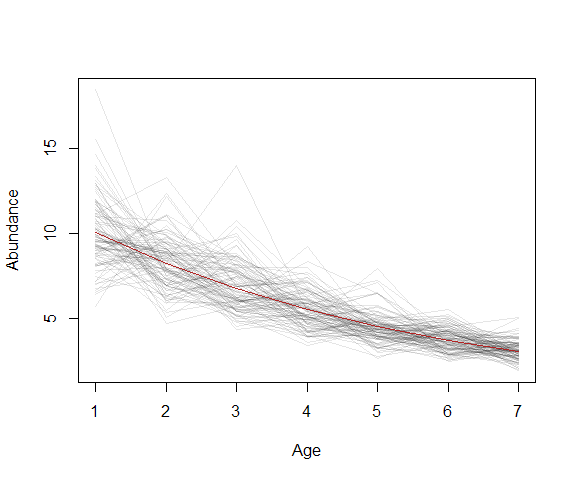

```r
## Plot 100 replicates
Rs <- replicate(n=100,
                expr=ageStructureS(R=rlnorm(n=8, meanlog=log(x=10), sdlog=0.2), Msf=Msf, M=M))
matplot(x=Rs,type="l", lty=1, col=rgb(0,0,0,0.1), xlab="Age", ylab="Abundance")
lines(x=ageStructureD(MMsf=M*Msf, R=exp(x=log(x=10)+0.1^2/2)), col="firebrick")
```

It can be more efficient to base each simulated profile on the previous but simulate forward fewer years.

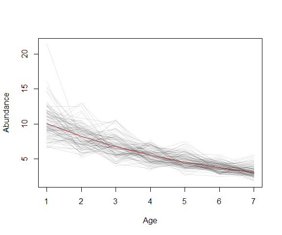

```r
Rs <- matrix(data=0, nrow=length(x=Ages), ncol=100)
Rs[,1] <- ageStructureS(R=rlnorm(n=8, meanlog=log(x=10), sdlog=0.2), Msf=Msf, M=M)
for(k in 2:ncol(x=Rs))
  Rs[,k] <- ageStructureS(R=rlnorm(n=8, meanlog=log(x=10), sdlog=0.2),Msf=Msf, M=M, N0=Rs[,k-1])
matplot(x=Rs, type="l", lty=1, col=rgb(0,0,0,0.1), xlab="Age", ylab="Abundance")
lines(x=ageStructureD(MMsf=M*Msf, R=exp(x=log(x=10)+0.1^2/2)), col="firebrick")
```

## Stock Summary

The `spawningStock` function extracts the spawning stock abundance or biomass from a projection, while `vulnerableStock` and `vulnerableStockGYM` extracts abundance or biomass vulnerable to fishing from a projection.

#### Setup

Define age classes and within year time steps

```r
## Daily time steps and 7 age classes
nsteps <- 365
Ages <- 2:8
Days <- seq(from=0, to=1, length=nsteps+1)
h <- 1/nsteps
```

Create matrices of age, length and weight for each time step and age class

```r
## Ages
ages <- outer(X=Days, Y=Ages, FUN="+")
## Age-length and length-weight conversions
ls <- vonBertalanffyAL(A=ages, t0=0.0667, K=0.5, Linf=500)
ws <- powerLW(L=ls, a=9E-10, b=3.32)
```

Define the normalized intra-annual natural mortality, its integral and the annual scaling

```r
## Constant intra-annual natural mortality
ms <- matrix(data=1, nrow=nsteps+1, ncol=length(x=Ages))
ms <- ms/mean(x=trapz(fs=ms, h=h))
Ms <- ctrapz(fs=ms, h=h)
Msf <- final(P=Ms)
M <- 0.1
```

```r
## Normalized within year distribution of fishing effort
fwy <- double(length=nsteps+1)
fwy[81:220] <- 1
fwy <- fwy/trapz(fs=fwy, h=h)
## Length based selectivity
ss <- rampOgive(x=ls, x50=420, xrange=30)
```

Define the normalized intra-annual fishing mortality, its integral and the annual scaling.

```r
## Intra-annual fishing mortality - effort by selectivity
fs <- fwy*ss
Fs <- ctrapz(fs=fs, h=h)
Fsf <- final(P=Fs)
F <- 0.2
```

Compute an intial age structure assuming constant mortalities and assuming no plus class

```r
## Deterministic initial age structure
N0 <- ageStructureD(MMsf=M*Msf, FFsf=F*Fsf)
N0
[1] 1.0000000 0.9048374 0.8040328 0.5956421 0.4412625 0.3268953 0.2421700
```

Project forward for a single year with known mortalities

```r
## Annual projection from N0
pr <- project(ws=ws, MMs=M*Ms, FFs=F*Fs, Ffs=F*fs, Nref=N0, yield=2)
```

#### Initial and Final

Extract the initial and final abundances in each age class

```r
## Initial abundance
initial(P=pr$N)
[1] 1.0000000 0.9048374 0.8040328 0.5956421 0.4412625 0.3268953 0.2421700
## Final abundance
final(P=pr$N)
[1] 0.9048374 0.8040328 0.5956421 0.4412625 0.3268953 0.2421700 0.1794040
```

#### Mean Stock

The mean total abundance and biomass from day 100 to 150 (time steps 101 to 150)

```r
monitor <- 101:150
## Mean total abundance in the monitoring period
meanStock(P=pr$N, period=monitor)
[1] 4.025763
## Mean total biomass in the monitoring period
meanStock(P=pr$B, period=monitor)
[1] 1.989678
```

#### Spawning Stock

Determine the fraction mature at age from length at age

```r
## Maturity at age
gs <- rampOgive(x=ls, x50=410, xrange=40)
```

If the spawning period is from day 200 to day 280 (time steps 201 to 281)

```r
## Increments in the spawning period
spawn <- 201:281
```

then the spawning stock abundance and biomass are

```r
## Spawning stock abundance
spawningStock(P=pr$N, gs=gs, period=spawn)
[1] 2.414319
## Spawning stock biomass
spawningStock(P=pr$B, gs=gs, period=spawn)
[1] 1.499233
```

#### Exploitable and Vulnerable Stock

The `exploitableStock` function calculates the mean abundance or biomass that can be exploited by scaling the abundance or biomass by selectivity, `vulnerableStock` computes the effort weighted mean exploitable stock abundance or biomass.

If the exploitable and vulnerable biomass are identical when fishing effort is constant within the monitoring period

```r
## Monitoring period within fishing season
monitor <- 101:151
## Exploitable biomass
exploitableStock(P=pr$B, ss=ss, period=monitor)
[1] 1.419356
## Weighted vulnerable biomass
vulnerableStock(P=pr$B, ss=ss, fwy=fwy, period=monitor)
[1] 1.419356
```

but may differ if the fishing effort varies varies within the monitoring period

```r
## Monitoring period spans fishing season
monitor <- 41:101
## Exploitable biomass
exploitableStock(P=pr$B, ss=ss, period=monitor)
[1] 1.498579
## Vulnerable biomass weights by effort
vulnerableStock(P=pr$B, ss=ss, fwy=fwy, period=monitor)
[1] 1.477055
```

If the monitoring period is outside the fishing season, vulnerable biomasss is zero

```r
## No effort in monitoring period
monitor <- 11:31
## Exploitable biomass
exploitableStock(P=pr$B, ss=ss, period=monitor)
[1] 1.460039
## Vulnerable biomass weights by effort
vulnerableStock(P=pr$B, ss=ss, fwy=fwy, period=monitor)
[1] 0
```

## spawningB0D

The `spawningB0D` function provides a deterministic estimate of the virgin spawning stock biomass by deterministically computing the virgin age structure and projecting forward to compute the spawning biomass.

#### Setup

Define age classes and within year time steps

```r
## Daily time steps and 7 age classes
nsteps <- 365
Ages <- 2:8
Days <- seq(from=0, to=1, length=nsteps+1)
h <- 1/nsteps
```

Create matrices of age, length and weight for each time step and age class

```r
## Ages
ages <- outer(X=Days, Y=Ages, FUN="+")
## Age-length and length-weight conversions
ls <- vonBertalanffyAL(A=ages, t0=0.0667, K=0.5, Linf=500)
ws <- powerLW(L=ls, a=9E-10, b=3.32)
```

Define the intra-annual natural mortality, its integral and the annual scaling

```r
## Constant intra-annual natural mortality
ms <- matrix(data=1, nrow=nsteps+1, ncol=length(x=Ages))
ms <- ms/mean(x=trapz(fs=ms, h=h))
Ms <- ctrapz(fs=ms, h=h)
Msf <- final(P=Ms)
M <- 0.128707
```

#### Virgin Spawning Biomass

Determine the fraction mature at age from length at age

```r
## Maturity at age
gs <- rampOgive(x=ls, x50=410, xrange=40)
```

If the spawing period is from day 200 to day 280 (time steps 201 to 281)

```r
## Increments in the spawning period
spawn <- 201:281
```

then the deterministic estimate of virgin spawning stock biomass is

```r
## Virgin spawning stock abundance
spawningB0D(gs=gs, ws=ws, MMs=M*Ms, spawn=spawn)
[1] 2.170942
```

## spawningB0S

The `spawningB0S` function provides a stochastic estimate of the virgin spawning stock biomass by repeatedly simulating the virgin age structure and projecting forward to compute the spawning biomass.

#### Setup

Define age classes and within year time steps

```r
## Daily time steps and 7 age classes
nsteps <- 365
Ages <- 2:8
Days <- seq(from=0,to=1,length=nsteps+1)
h <- 1/nsteps
```

Create matrices of age, length and weight for each time step and age class

```r
## Ages
ages <- outer(X=Days,Y=Ages,FUN="+")
## Age-length and length-weight conversions
ls <- vonBertalanffyAL(A=ages,t0=0.0667,K=0.5,Linf=500)
ws <- powerLW(L=ls, a=9E-10, b=3.32)
```

Define the intra-annual natural mortality, its integral and the annual scaling

```r
## Constant intra-annual natural mortality
ms <- matrix(data=1,nrow=nsteps+1,ncol=length(Ages))
ms <- ms/mean(x=trapz(fs=ms,h=h))
Ms <- ctrapz(fs=ms,h=h)
Msf <- final(P=Ms)
```

#### Random Recruits

```r
## Compute model parameters that give mean R = 0.3 and var R = 0.01,
## when R is the proportion of recruits in the population
ps <- prRecruitParsIB(Msf=Msf,mnR=0.2,vrR=0.01)
## Estimated natural mortality scaling
ps$M
[1] 0.128707
```

Generate 1000 sets of 10 recruitment events

```r
R <- matrix(data=prRecruitsIB(n=10000,ps=ps),nrow=1000,ncol=10)
```

#### Virgin Spawning Biomass

Determine the fraction mature at age from length at age

```r
## Maturity at age
gs <- rampOgive(x=ls,x50=410,xrange=40)
```

If the spawing period is from day 200 to day 280 (time steps 201 to 281)

```r
## Increments in the spawning period
spawn <- 201:281
```

then estimates of the median, mean and standard deviation of the virgin spawning stock biomass are

```r
## Virgin spawning stock abundance
spawningB0S(R=R,gs=gs,ws=ws,Ms=Ms,M=ps$M,spawn=spawn)
$median
[1] 2.107054

$mean
[1] 2.180703

$sd
[1] 0.5198212

$n
[1] 1000
```

## prRecruits

Grym offers several variants of the proportional recruitment model implemented in the GYM.

Let $A_{k}$ be the number of individuals in age class $k$ and define
$$R = \frac{A_{r}}{\sum_{k=r} A_{k}}$$
the number of individuals in age class $r$ as a proportion of all individuals of that age or older. Given estimates of the mean and variance of $R$ from independent surveys, the proportional recruitment model determines the scaling of natural mortality M and the distribution of random recruits that will reproduce the observed mean and variance of R.

#### Setup

Define age classes and within year time steps

```r
## Daily time steps and 7 age classes
nsteps <- 365
Ages <- 2:8
Days <- seq(from=0, to=1, length=nsteps+1)
h <- 1/nsteps
```

Create matrices of age, length and weight for each time step and age class

```r
## Ages
ages <- outer(X=Days, Y=Ages, FUN="+")
## Age-length and length-weight conversions
ls <- vonBertalanffyAL(A=ages, t0=0.0667, K=0.5, Linf=500)
ws <- powerLW(L=ls, a=9E-10, b=3.32)
```

Define the intra-annual natural mortality, its integral and the annual scaling

```r
## Constant intra-annual natural mortality
ms <- matrix(data=1, nrow=nsteps+1, ncol=length(x=Ages))
ms <- ms/mean(x=trapz(fs=ms, h=h))
Ms <- ctrapz(fs=ms, h=h)
Msf <- final(P=Ms)
```

Let $R$ be the proportion of the number of recruits as a fraction of the total population.

#### Inverse Beta

Generate model parameters from the mean and variance of $R$. This computes an estimate of the scaling of natural mortality required to reproduce the observed $R$.

```r
## Compute model parameters that give mean R = 0.3 and var R = 0.1,
## where R is the proportion of recruits in the population
ps <- prRecruitParsIB(Msf=Msf, mnR=0.3, vrR=0.01)
## Estimated natural mortality scaling
ps$M
[1] 0.3194035
```

Compute the median number of recruits

```r
## Median number of recruits
prRecruitsQuantileIB(q=0.5, ps=ps, mnA=100)
[1] 92.7501
```

Random numbers of recruits are generated from the estimated parameters

```r
## Ten random recruit numbers
prRecruitsIB(10, ps, mnA=100)
 [1] 121.16984  82.49616  55.64667  98.97758 131.58213 146.98444  64.31043
 [8]  66.48579 134.49278  97.73821
```

Check the random numbers of recruits have the required mean

```r
## Mean number of recruits
mean(x=prRecruitsIB(n=10000, ps=ps, mnA=100))
[1] 99.55437
```

Simulate the 10000 stochastic age profiles with this distribution of recruits and check the the observed mean and variance of $R$ are reproduced

```r
## Simulate age profiles and calculate R
N <- matrix(data=0, nrow=10000, ncol=ncol(x=Ms))
for(k in 1:nrow(x=N))
  N[k, ] <- ageStructureS(R=prRecruitsIB(n=ncol(x=Ms), ps=ps, mnA=100), Msf=Msf, M=ps$M)
R <- N[, 1]/rowSums(x=N)
## Estimate mean and variance of R
mean(R)
[1] 0.3012398
var(R)
[1] 0.008835439
```

The random recruits have a scaled inverse Beta distribution

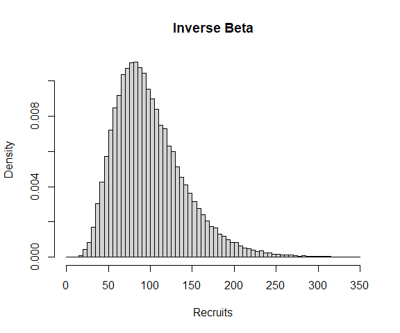

```r
## Histogram of simulated recruitments
rs <- prRecruitsIB(n=100000, ps=ps, mnA=100)
hist(x=rs[rs < 350], breaks=seq(from=0, to=350, by=5), freq=FALSE,
     xlab="Recruits", main="Inverse Beta")
```

Repeat for the case where R is the proportion of individuals in age class 3 as a fraction of individuals of that age or older,

```r
## Compute model parameters that give mean R = 0.3 and var R = 0.01,
## where R is the proportion of individual in age class 3 as a fraction
## of individuals that are that age or older
ps <- prRecruitParsIB(Msf=Msf, mnR=0.3, vrR=0.01, r=3)
## Estimated natural mortality scaling
ps$M
[1] 0.2380231
```

Compute the median number of recruits

```r
## Median number of recruits
prRecruitsQuantileIB(q=0.5, ps=ps, mnA=100)
[1] 93.15843
```

Random numbers of recruits are generated from the estimated parameters

```r
## Ten random recruit numbers
prRecruitsIB(n=10, ps=ps, mnA=100)
 [1]  99.87303 114.85695 181.50173 134.45551  88.79464 110.89615  65.72788
 [8]  88.10835 109.33208  53.11321
```

Check the random numbers of recruits have the required mean

```r
## Mean number of recruits
mean(x=prRecruitsIB(n=10000, ps=ps, mnA=100))
[1] 99.68291
```

Simulate the 10000 stochastic age profiles with this distribution of recruits and check the the observed mean and variance of $R$ are reproduced

```r
## Simulate age profiles and calculate R
N <- matrix(data=0, nrow=10000, ncol=ncol(x=Ms))
for(k in 1:nrow(x=N))
  N[k, ] <- ageStructureS(R=prRecruitsIB(n=ncol(x=Ms), ps=ps, mnA=100), Msf=Msf, M=ps$M)
R <- N[, 3]/rowSums(x=N[, 3:7])
## Estimate mean and variance of R
mean(x=R)
[1] 0.2990489
var(x=R)
[1] 0.008821802
```

#### Gamma

Generate model parameters from the mean and variance of $R$. This computes an estimate of the scaling of natural mortality required to reproduce the observed $R$.

```r
## Compute model parameters that give mean R = 0.3 and var R = 0.01,
## where R is the proportion of recruits in the population
ps <- prRecruitParsG(Msf=Msf, mnR=0.3, vrR=0.01)
## Estimated natural mortality scaling
ps$M
[1] 0.3194035
```

Compute the median number of recruits

```r
## Median number of recruits
prRecruitsQuantileG(q=0.5, ps=ps, mnA=100)
[1] 93.98026
```

Random numbers of recruits are generated from the estimated parameters

```r
## Ten random recruit numbers
prRecruitsG(n=10, ps=ps, mnA=100)
 [1]  47.95581 131.35864  64.81431 147.69596 125.00034  86.43059 105.04529
 [8]  38.40427  88.12249  67.80620
```

Check the random numbers of recruits have the required mean

```r
## Mean number of recruits
mean(x=prRecruitsG(n=10000, ps=ps, mnA=100))
[1] 99.57206
```

Simulate the 10000 stochastic age profiles with this distribution of recruits and check the the observed mean and variance of $R$ are reproduced

```r
## Simulate age profiles and calculate R
N <- matrix(data=0, nrow=10000, ncol=ncol(x=Ms))
for(k in 1:nrow(x=N))
  N[k, ] <- ageStructureS(R=prRecruitsG(n=ncol(x=Ms), ps=ps, mnA=100), Msf=Msf, M=ps$M)
R <- N[, 1]/rowSums(x=N)
## Estimate mean and variance of R
mean(x=R)
[1] 0.2988257
var(x=R)
[1] 0.009180646
```

The random recruits have a scaled Gamma distribution

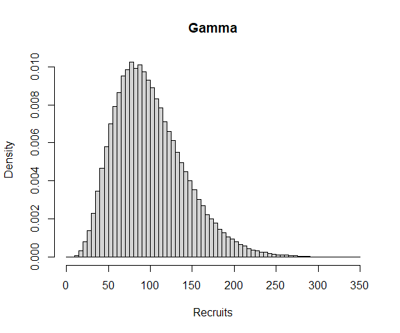

```r
## Histogram of simulated recruitments
rs <- prRecruitsG(100000, ps, mnA=100)
hist(x=rs[rs < 350], breaks=seq(from=0, to=350, by=5), freq=FALSE,
     xlab="Recruits", main="Gamma")
```

Repeat for the case where R is the proportion of individuals in age class 3 as a fraction of individuals of that age or older,

```r
## Compute model parameters that give mean R = 0.3 and var R = 0.01,
## where R is the proportion of individual in age class 3 as a fraction
## of individuals that are that age or older
ps <- prRecruitParsG(Msf=Msf, mnR=0.3, vrR=0.01, r=3)
## Estimated natural mortality scaling
ps$M
[1] 0.2380231
```

Compute the median number of recruits

```r
## Median number of recruits
prRecruitsQuantileG(q=0.5, ps=ps, mnA=100)
[1] 94.199
```

Random numbers of recruits are generated from the estimated parameters

```r
## Ten random recruit numbers
prRecruitsG(n=10, ps=ps, mnA=100)
 [1]  82.13868  91.81470 164.77452  70.93751 101.17111 104.99778 107.32945
 [8]  96.22542 140.81820 118.73134
```

Check the random numbers of recruits have the required mean

```r
## Mean number of recruits
mean(x=prRecruitsG(n=10000, ps=ps, mnA=100))
[1] 99.66465
```

Simulate the 10000 stochastic age profiles with this distribution of recruits and check the the observed mean and variance of $R$ are reproduced

```r
## Simulate age profiles and calculate R
N <- matrix(data=0, nrow=10000, ncol=ncol(x=Ms))
for(k in 1:nrow(x=N))
  N[k, ] <- ageStructureS(R=prRecruitsG(n=ncol(x=Ms), ps=ps, mnA=100), Msf=Msf, M=ps$M)
R <- N[, 3]/rowSums(x=N[, 3:7])
## Estimate mean and variance of R
mean(x=R)
[1] 0.2998214
var(x=R)
[1] 0.009164845
```

#### Log Normal

Generate model parameters from the mean and variance of $R$. This computes an estimate of the scaling of natural mortality required to reproduce the observed $R$.

```r
## Compute model parameters that give mean R = 0.3 and var R = 0.01,
## where R is the proportion of recruits in the population
ps <- prRecruitParsLN(Msf=Msf, mnR=0.3, vrR=0.01)
## Estimated natural mortality scaling
ps$M
[1] 0.3194035
```

Compute the median number of recruits

```r
## Median number of recruits
prRecruitsQuantileLN(q=0.5, ps=ps, mnA=100)
[1] 91.95218
```

Random numbers of recruits are generated from the estimated parameters

```r
## Ten random recruit numbers
prRecruitsLN(n=10, ps=ps, mnA=100)
 [1]  70.03426  90.31430  37.23728 170.68152 193.92654 183.99660 124.41539
 [8] 111.44149  46.14821  94.58675
```

Check the random numbers of recruits have the required mean

```r
## Mean number of recruits
mean(x=prRecruitsLN(n=10000, ps=ps, mnA=100))
[1] 99.48148
```

Simulate the 10000 stochastic age profiles with this distribution of recruits and check the the observed mean and variance of $R$ are reproduced

```r
## Simulate age profiles and calculate R
N <- matrix(data=0, nrow=10000, ncol=ncol(x=Ms))
for(k in 1:nrow(x=N))
  N[k, ] <- ageStructureS(R=prRecruitsLN(n=ncol(x=Ms), ps=ps, mnA=100), Msf=Msf, M=ps$M)
R <- N[, 1]/rowSums(x=N)
## Estimate mean and variance of R
mean(x=R)
[1] 0.300395
var(x=R)
[1] 0.008408916
```

The random recruits have a scaled log Normal distribution

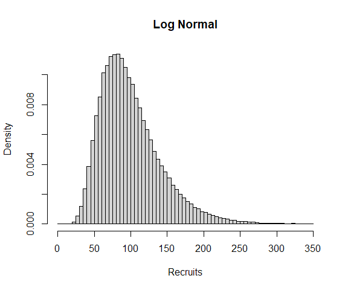

```r
## Histogram of simulated recruitments
rs <- prRecruitsLN(n=100000, ps=ps, mnA=100)
hist(x=rs[rs < 350], breaks=seq(from=0, to=350, by=5), freq=FALSE,
     xlab="Recruits", main="Log Normal")
```

Repeat for the case where R is the proportion of individuals in age class 3 as a fraction of individuals of that age or older,

```r
## Compute model parameters that give mean R = 0.3 and var R = 0.01,
## where R is the proportion of individual in age class 3 as a fraction
## of individuals that are that age or older
ps <- prRecruitParsLN(Msf=Msf, mnR=0.3, vrR=0.01, r=3)
## Estimated natural mortality scaling
ps$M
[1] 0.2380231
```

Compute the median number of recruits

```r
## Median number of recruits
prRecruitsQuantileLN(q=0.5, ps=ps, mnA=100)
[1] 92.2145
```

Random numbers of recruits are generated from the estimated parameters

```r
## Ten random recruit numbers
prRecruitsLN(n=10, ps=ps, mnA=100)
 [1]  57.91752 143.67652  61.01580 102.38207  93.51532  95.95471  69.80746
 [8]  86.74414 127.51763 127.27516
```

Check the random numbers of recruits have the required mean

```r
## Mean number of recruits
mean(x=prRecruitsLN(n=10000, ps=ps, mnA=100))
[1] 99.90546
```

Simulate the 10000 stochastic age profiles with this distribution of recruits and check the the observed mean and variance of $R$ are reproduced

```r
## Simulate age profiles and calculate R
N <- matrix(data=0, nrow=10000, ncol=ncol(x=Ms))
for(k in 1:nrow(x=N))
  N[k, ] <- ageStructureS(R=prRecruitsLN(n=ncol(x=Ms), ps=ps, mnA=100), Msf=Msf, M=ps$M)
R <- N[, 3]/rowSums(x=N[, 3:7])
## Estimate mean and variance of R
mean(x=R)
[1] 0.301536
var(x=R)
[1] 0.008595881
```

#### Delta Inverse Beta

The Delta-Inverse Beta model may provide a closer fit to abundance data with a zero-inflated distribution.

Generate model parameters from the mean and variance of $R$. This computes an estimate of the scaling of natural mortality required to reproduce the observed $R$.

```r
## Compute model parameters that give mean R = 0.3 and var R = 0.2,
## where R is the proportion of recruits in the population,  assuming
## zero recruitment occurs with probability 0.4
ps <- prRecruitParsDIB(Msf=Msf, mnR=0.3, vrR=0.2, p=0.4)
## Estimated natural mortality scaling
ps$M
[1] 0.672917
```

Compute the median number of recruits

```r
## Median number of recruits
prRecruitsQuantileDIB(q=0.5, ps=ps, mnA=100)
       p
59.01825
```

Random numbers of recruits are generated from the estimated parameters

```r
## Ten random recruit numbers
prRecruitsDIB(n=10, ps=ps, mnA=100)
 [1]  38.20917 193.51155 104.01912  68.26150   0.00000 110.69392  35.18797
 [8] 186.20534 333.63738  84.55518
```

Check the random numbers of recruits have the required mean

```r
## Mean number of recruits
mean(x=prRecruitsDIB(n=10000, ps=ps, mnA=100))
[1] 97.57158
```

Simulate the 10000 stochastic age profiles with this distribution of recruits and check the the observed mean and variance of $R$ are reproduced

```r
## Simulate age profiles and calculate R
N <- matrix(data=0, nrow=10000, ncol=ncol(x=Ms))
for(k in 1:nrow(x=N))
  N[k, ] <- ageStructureS(R=prRecruitsDIB(n=ncol(x=Ms), ps=ps, mnA=100), Msf=Msf, M=ps$M)
R <- N[, 1]/rowSums(x=N)
## Estimate mean and variance of R
mean(x=R, na.rm=TRUE)
[1] 0.3602963
var(x=R, na.rm=TRUE)
[1] 0.1162541
```

The random non-zero recruitment events have a scaled Inverse Beta distribution

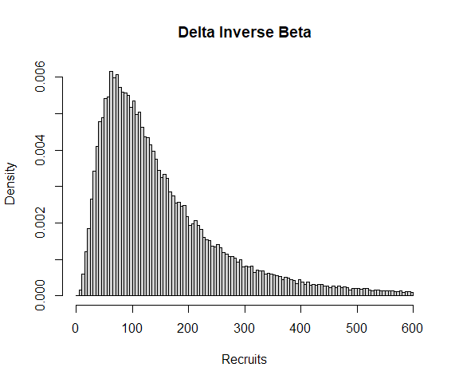

```r
## Histogram of simulated recruitments
rs <- prRecruitsDIB(n=100000, ps=ps, mnA=100)
hist(x=rs[rs >0 & rs < 600], breaks=seq(from=0, to=600, by=5), freq=FALSE,
     xlab="Recruits", main="Delta Inverse Beta")
```

But there are many zero recruitment events

```r
## Fraction of zero recruitments
mean(x=rs==0)
[1] 0.39841
```

Repeat for the case where R is the proportion of individuals in age class 3 as a fraction of individuals of that age or older,

```r
## Compute model parameters that give mean R = 0.3 and var R = 0.2,
## where R is the proportion of individual in age class 3 as a fraction
## of individuals that are that age or older,  assuming
## recruitment occurs with probability 0.4
ps <- prRecruitParsDIB(Msf=Msf, mnR=0.3, vrR=0.2, p=0.4, r=3)
## Estimated natural mortality scaling
ps$M
[1] 0.5928293
```

Compute the median number of recruits

```r
## Median number of recruits
prRecruitsQuantileDIB(q=0.5, ps=ps, mnA=100)
       p
57.55216
```

Random numbers of recruits are generated from the estimated parameters

```r
## Ten random recruit numbers
prRecruitsDIB(n=10, ps=ps, mnA=100)
 [1] 147.04462 202.77530  88.33009   0.00000   0.00000 302.57858   0.00000
 [8]   0.00000 278.37799  98.87451
```

Check the random numbers of recruits have the required mean

```r
## Mean number of recruits
mean(x=prRecruitsDIB(n=10000, ps=ps, mnA=100))
[1] 99.74441
```

Simulate the 10000 stochastic age profiles with this distribution of recruits and check the the observed mean and variance of $R$ are reproduced

```r
## Simulate age profiles and calculate R
N <- matrix(data=0, nrow=10000, ncol=ncol(x=Ms))
for(k in 1:nrow(x=N))
  N[k, ] <- ageStructureS(R=prRecruitsDIB(n=ncol(x=Ms), ps=ps, mnA=100), Msf=Msf, M=ps$M)
R <- N[, 3]/rowSums(x=N[, 3:7])
## Estimate mean and variance of R
mean(x=R, na.rm=TRUE)
[1] 0.353864
var(x=R, na.rm=TRUE)
[1] 0.1139425
```

#### Delta Gamma

The Delta-Gamma model may provide a closer fit to abundance data with a zero-inflated distribution.

Generate model parameters from the mean and variance of $R$. This computes an estimate of the scaling of natural mortality required to reproduce the observed $R$.

```r
## Compute model parameters that give mean R = 0.3 and var R = 0.2,
## where R is the proportion of recruits in the population,  assuming
## zero recruitment occurs with probability 0.4
ps <- prRecruitParsDG(Msf=Msf, mnR=0.3, vrR=0.2, p=0.4)
## Estimated natural mortality scaling
ps$M
[1] 0.672917
```

Compute the median number of recruits

```r
## Median number of recruits
prRecruitsQuantileDG(q=0.5, ps=ps, mnA=100)
       p
28.85033
```

Random numbers of recruits are generated from the estimated parameters

```r
## Ten random recruit numbers
prRecruitsDG(n=10, ps=ps, mnA=100)
 [1] 312.16882   0.00000  19.32383   0.00000  91.93703   0.00000   0.00000
 [8]   0.00000 243.83228  13.60090
```

Check the random numbers of recruits have the required mean

```r
## Mean number of recruits
mean(x=prRecruitsDG(n=10000, ps=ps, mnA=100))
[1] 99.71009
```

Simulate the 10000 stochastic age profiles with this distribution of recruits and check the the observed mean and variance of $R$ are reproduced

```r
## Simulate age profiles and calculate R
N <- matrix(data=0, nrow=10000, ncol=ncol(x=Ms))
for(k in 1:nrow(x=N))
  N[k, ] <- ageStructureS(R=prRecruitsDG(n=ncol(x=Ms), ps=ps, mnA=100), Msf=Msf, M=ps$M)
R <- N[, 1]/rowSums(x=N)
## Estimate mean and variance of R
mean(x=R, na.rm=TRUE)
[1] 0.3341936
var(x=R, na.rm=TRUE)
[1] 0.1216959
```

The non-zero recruits have a scaled Gamma distribution

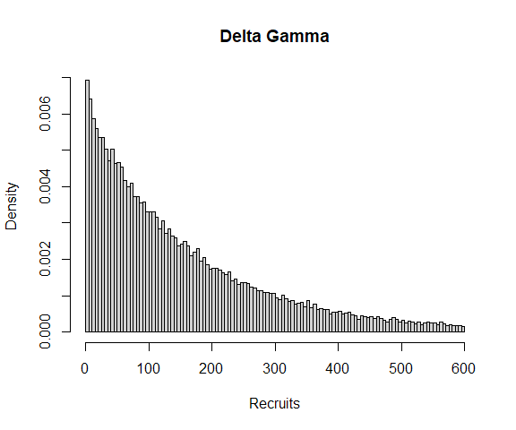

```r
## Histogram of simulated recruitments
rs <- prRecruitsDG(n=100000, ps=ps, mnA=100)
hist(x=rs[rs >0 & rs < 600], breaks=seq(from=0, to=600, by=5), freq=FALSE,
     xlab="Recruits", main="Delta Gamma")
```

But there are many zero recruitment events

```r
## Fraction of zero recruitments
mean(x=rs==0)
[1] 0.40147
```

Repeat for the case where R is the proportion of individuals in age class 3 as a fraction of individuals of that age or older,

```r
## Compute model parameters that give mean R = 0.3 and var R = 0.2,
## where R is the proportion of individual in age class 3 as a
## fraction of individuals that are that age or older, assuming
## recruitment occurs with probability 0.4
ps <- prRecruitParsDG(Msf=Msf, mnR=0.3, vrR=0.2, p=0.4, r=3)
## Estimated natural mortality scaling
ps$M
[1] 0.5928293
```

Compute the median number of recruits

```r
## Median number of recruits
prRecruitsQuantileDG(q=0.5, ps=ps, mnA=100)
       p
28.98105
```

Random numbers of recruits are generated from the estimated parameters

```r
## Ten random recruit numbers
prRecruitsDG(n=10, ps=ps, mnA=100)
 [1]   0.000000  17.586002  45.509807   1.563489  55.452682   0.000000
 [7] 170.759978  47.564883 122.961279 737.597964
```

Check the random numbers of recruits have the required mean

```r
## Mean number of recruits
mean(x=prRecruitsDG(n=10000, ps=ps, mnA=100))
[1] 99.67476
```

Simulate the 10000 stochastic age profiles with this distribution of recruits and check the the observed mean and variance of $R$ are reproduced

```r
## Simulate age profiles and calculate R
N <- matrix(data=0, nrow=10000, ncol=ncol(x=Ms))
for(k in 1:nrow(x=N))
  N[k, ] <- ageStructureS(R=prRecruitsDG(n=ncol(x=Ms), ps=ps, mnA=100), Msf=Msf, M=ps$M)
R <- N[, 3]/rowSums(x=N[, 3:7])
## Estimate mean and variance of R
mean(x=R, na.rm=TRUE)
[1] 0.3418417
var(x=R, na.rm=TRUE)
[1] 0.1238791
```

#### Delta Log Normal

The Delta-Log Normal model may provide a closer fit to abundance data with a zero-inflated distribution.

Generate model parameters from the mean and variance of $R$. This computes an estimate of the scaling of natural mortality required to reproduce the observed $R$.

```r
## Compute model parameters that give mean R = 0.3 and var R = 0.2,
## where R is the proportion of recruits in the population,  assuming
## zero recruitment events occur with probability 0.4.
ps <- prRecruitParsDLN(Msf=Msf, mnR=0.3, vrR=0.1, p=0.4)
## Estimated natural mortality scaling
ps$M
[1] 0.4421236
```

Compute the median number of recruits

```r
## Median number of recruits
prRecruitsQuantileDLN(q=0.5, ps=ps, mnA=100)
       p
75.09216
```

Random numbers of recruits are generated from the estimated parameters

```r
## Ten random recruit numbers
prRecruitsDLN(n=10, ps=ps, mnA=100)
 [1] 259.5750   0.0000   0.0000   0.0000 335.9997   0.0000 120.3845 127.0030
 [9] 252.9682   0.0000
```

Check the random numbers of recruits have the required mean

```r
## Mean number of recruits
mean(x=prRecruitsDLN(n=10000, ps=ps, mnA=100))
[1] 97.22721
```

Simulate the 10000 stochastic age profiles with this distribution of recruits and check the the observed mean and variance of $R$ are reproduced

```r
## Simulate age profiles and calculate R
N <- matrix(data=0, nrow=10000, ncol=ncol(x=Ms))
for(k in 1:nrow(x=N))
  N[k, ] <- ageStructureS(R=prRecruitsDLN(n=ncol(x=Ms), ps=ps, mnA=100), Msf=Msf, M=ps$M)
R <- N[, 1]/rowSums(x=N)
## Estimate mean and variance of R
mean(x=R, na.rm=TRUE)
[1] 0.3014592
var(x=R, na.rm=TRUE)
[1] 0.08373143
```

The non-zero recruits have a scaled Log Normal distribution

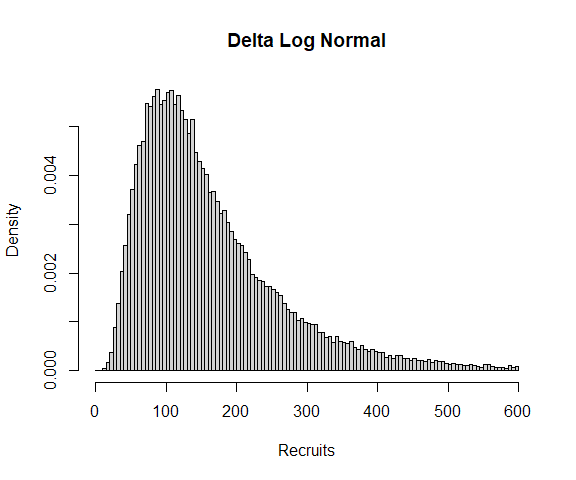

```r
## Histogram of simulated recruitments
rs <- prRecruitsDLN(n=100000, ps=ps, mnA=100)
hist(x=rs[rs >0 & rs < 600], breaks=seq(from=0, to=600, by=5), freq=FALSE,
     xlab="Recruits", main="Delta Log Normal")
```

But there are many zero recruitment events

```r
## Fraction of zero recruitments
mean(x=rs==0)
[1] 0.39944
```

Repeat for the case where R is the proportion of individuals in age class 3 as a fraction of individuals of that age or older,

```r
## Compute model parameters that give mean R = 0.3 and var R = 0.2,
## where R is the proportion of individual in age class 3 as a
## fraction of individuals that are that age or older,  assuming
## recruitment occurs with probability 0.4
ps <- prRecruitParsDLN(Msf=Msf, mnR=0.3, vrR=0.2, p=0.4, r=3)
## Estimated natural mortality scaling
ps$M
[1] 0.5928293
```

Compute the median number of recruits

```r
## Median number of recruits
prRecruitsQuantileDLN(q=0.5, ps=ps, mnA=100)
       p
51.71143
```

Random numbers of recruits are generated from the estimated parameters

```r
## Ten random recruit numbers
prRecruitsDLN(n=10, ps=ps, mnA=100)
 [1]  90.37003 145.78132 121.32093   0.00000 107.94463 410.98623   0.00000
 [8]   0.00000   0.00000  21.98529
```

Check the random numbers of recruits have the required mean

```r
## Mean number of recruits
mean(x=prRecruitsDLN(n=10000, ps=ps, mnA=100))
[1] 99.81055
```

Simulate the 10000 stochastic age profiles with this distribution of recruits and check the the observed mean and variance of $R$ are reproduced

```r
## Simulate age profiles and calculate R
N <- matrix(data=0, nrow=10000, ncol=ncol(x=Ms))
for(k in 1:nrow(x=N))
  N[k, ] <- ageStructureS(R=prRecruitsDLN(n=ncol(x=Ms), ps=ps, mnA=100), Msf=Msf, M=ps$M)
R <- N[, 3]/rowSums(x=N[, 3:7])
## Estimate mean and variance of R
mean(x=R, na.rm=TRUE)
[1] 0.3494208
var(x=R, na.rm=TRUE)
[1] 0.1156286
```

## prRecruitsGYM

Grym offers the same proprtional recruitment model based on the Beta distribution offered in the GYM.

Let $A_{k}$ be the number of individuals in age class $k$ and define
$$R = \frac{A_{r}}{\sum_{k=r} A_{k}}$$
the number of individuals in age class $r$ as a poportion of all individuals of that age or older. Given estimates of the mean and variance of $R$ from independent surveys, the proportional recruitment model determines the scaling of natural mortality M and the distribution of random recruits that will reproduce the observed mean and variance of R.

#### Setup

Define age classes and within year time steps

```r
## Daily time steps and 7 age classes
nsteps <- 365
Ages <- 2:8
Days <- seq(from=0, to=1, length=nsteps+1)
h <- 1/nsteps
```

Create matrices of age, length and weight for each time step and age class

```r
## Ages
ages <- outer(X=Days, Y=Ages, FUN="+")
## Age-length and length-weight conversions
ls <- vonBertalanffyAL(A=ages, t0=0.0667, K=0.5, Linf=500)
ws <- powerLW(L=ls, a=9E-10, b=3.32)
```

Define the intra-annual natural mortality, its integral and the annual scaling

```r
## Constant intra-annual natural mortality
ms <- matrix(data=1, nrow=nsteps+1, ncol=length(x=Ages))
ms <- ms/mean(x=trapz(fs=ms, h=h))
Ms <- ctrapz(fs=ms, h=h)
Msf <- final(P=Ms)
M <- 0.2
```

#### GYM

Let $R$ be the proportion of the number of recruits as a fraction of the total population.

Generate model parameters from the mean and variance of R. This computes an estimate of the scaling of natural mortality required to reproduce the observed $R$.

```r
## Compute model parameters that give mean R = 0.3 and var R = 0.01,
## when R is the proportion of recruits in the population
ps <- prRecruitParsGYM(Msf=Msf, mnR=0.3, vrR=0.01)
## Estimated natural mortality scaling
ps$M
[1] 0.3263206
```

Compute the median number of recruits

```r
## Median number of recruits
prRecruitsQuantileGYM(q=0.5, ps=ps, mnA=100)
[1] 91.30353
```

Random numbers of recruits are generated from the estimate parameters

```r
## Ten random recruit numbers
prRecruitsGYM(n=10, ps=ps, mnA=100)
 [1]  62.29769  84.45320  71.07065 115.77917 103.97052  73.24396  85.78217
 [8]  45.40749 134.28544 110.05103
```

Check the random numbers of recruits have the required mean

```r
## Mean number of recruits
mean(x=prRecruitsGYM(n=10000, ps=ps, mnA=100))
[1] 99.50657
```

```r
## Simulate age profiles and calculate R
N <- matrix(data=0, nrow=10000, ncol=ncol(x=Ms))
for(k in 1:nrow(x=N))
  N[k, ] <- ageStructureS(R=prRecruitsGYM(n=10, ps=ps, mnA=100), Msf=Msf, M=ps$M)
R <- N[, 1]/rowSums(x=N)
## Estimate mean and variance of R
mean(x=R)
[1] 0.3042464
var(x=R)
[1] 0.01079361
```

The random recruits have a scaled inverse Beta distribution

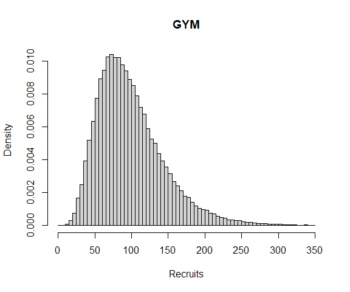

```r
## Histogram of simulated recruitments
rs <- prRecruitsGYM(n=100000, ps=ps, mnA=100)
hist(x=rs[rs < 350], seq(from=0, to=350, by=5), freq=FALSE, xlab="Recruits", main="GYM")
```

Repeat for the case where R is the proportion of individuals in age class 3 as a fraction of individuals of that age or older,

```r
## Compute model parameters that give mean R = 0.3 and var R = 0.01,
## when R is the proportion of individual in age class 3 as a fraction
## of individuals that are that age or older
ps <- prRecruitParsGYM(mnR=0.3, vrR=0.01, Msf=Msf, r=3)
## Estimated natural mortality scaling
ps$M
[1] 0.2499531
```

Compute the median number of recruits

```r
## Median number of recruits
prRecruitsQuantileGYM(q=0.5, ps=ps, mnA=100)
[1] 112.4347
```

Random numbers of recruits are generated from the estimate parameters

```r
## Ten random recruit numbers
prRecruitsGYM(n=10, ps=ps, mnA=100)
 [1] 123.85772 218.81497 151.49323  69.54213 135.28992 185.02084 117.99435
 [8]  81.54494  39.11656 155.28766
```

Check the random numbers of recruits have the required mean

```r
## Mean number of recruits
mean(x=prRecruitsGYM(n=10000, ps=ps, mnA=100))
[1] 122.2142
```

```r
## Simulate age profiles and calculate R
N <- matrix(data=0, nrow=100000, ncol=ncol(x=Ms))
for(k in 1:nrow(x=N))
  N[k, ] <- ageStructureS(R=prRecruitsGYM(n=10, ps=ps, mnA=100), Msf=Msf, M=ps$M)
R <- N[, 3]/rowSums(x=N[, 3:7])
## Estimate mean and variance of R
mean(x=R)
[1] 0.3048335
var(x=R)
[1] 0.01035281
```

## prBootstrap

Let $A_{k}$ be the number of individuals in age class $k$ and define
$$R = \frac{A_{r}}{\sum_{k=r} A_{k}}$$
the number of individuals in age class $r$ as a poportion of all individuals of that age or older.

The proportional1 recruitment model assumes estimates of the mean and variance of $R$ from independent surveys. To allow for uncertainty in these estimates, `prBootstrap` uses parametric bootstrap to simulates new values for the mean and variance of $R$ that are consistent with the observed values.

#### Setup

Define age classes and within year time steps

```r
## Daily time steps and 7 age classes
nsteps <- 365
Ages <- 2:8
Days <- seq(from=0, to=1, length=nsteps+1)
h <- 1/nsteps
```

Create matrices of age, length and weight for each time step and age class

```r
## Ages
ages <- outer(X=Days, Y=Ages, FUN="+")
## Age-length and length-weight conversions
ls <- vonBertalanffyAL(A=ages, t0=0.0667, K=0.5, Linf=500)
ws <- powerLW(L=ls, a=9E-10, b=3.32)
```

Define the intra-annual natural mortality, its integral and the annual scaling

```r
## Constant intra-annual natural mortality
ms <- matrix(data=1, nrow=nsteps+1, ncol=length(x=Ages))
ms <- ms/mean(x=trapz(fs=ms, h=h))
Ms <- ctrapz(fs=ms, h=h)
Msf <- final(P=Ms)
M <- 0.2
```

#### Inverse Beta

Generate model parameters from the observed mean and variance of R assuming the Inverse Beta model

```r
## Compute model parameters that give mean R = 0.3 and var R = 0.01,
## when R is the proportion of recruits in the population
ps <- prRecruitParsIB(mnR=0.3, vrR=0.01, Msf=Msf)
```

Simulate a new values for the mean and variance on which subsequent projections could be based, assuming the original estimates were generated from 17 independent survey

```r
## Simulate new mean and variance for 17 surveys
prBootstrap(prRec=prRecruitsIB, ps=ps, n=17, Msf=Msf)
$mnR
[1] 0.2994858

$vrR
[1] 0.007470455

$p
[1] 0

$n
[1] 17

$r
[1] 1
```

Generate 2000 bootstrap samples and examine the distribution of the simulated mean and variance

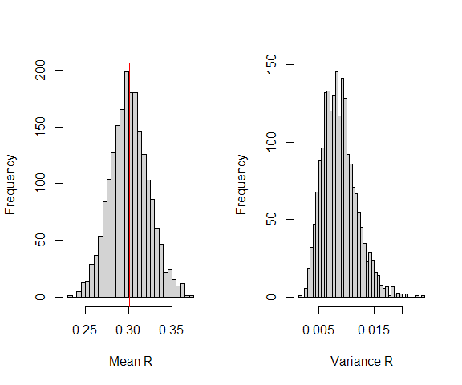

```r
## Distribution of 2000 samples
bs <- replicate(n=2000, expr=unlist(x=prBootstrap(prRec=prRecruitsIB, ps=ps, n=17, Msf=Msf)))
opar <- par(mfrow=c(1,2))
hist(x=bs[1,], breaks=50, xlab="Mean R", main="")
abline(v=median(bs[1,]), col="red")
hist(x=bs[2,], breaks=50, xlab="Variance R", main="")
abline(v=median(x=bs[2,]), col="red")
par(opar)
```

#### Gamma

Generate model parameters from the observed mean and variance of R assuming the Gamma model

```r
## Compute model parameters that give mean R = 0.3 and var R = 0.01,
## when R is the proportion of recruits in the population
ps <- prRecruitParsG(mnR=0.3, vrR=0.01, Msf=Msf)
```

Simulate a new values for the mean and variance on which subsequent projections could be based, assuming the original estimates were generated from 17 independent survey

```r
## Simulate new mean and variance for 17 surveys
prBootstrap(prRec=prRecruitsG, ps=ps, n=17, Msf=Msf)
$mnR
[1] 0.2961642

$vrR
[1] 0.007061854

$p
[1] 0

$n
[1] 17

$r
[1] 1
```

Generate 2000 bootstrap samples and examine the distribution of the simulated mean and variance

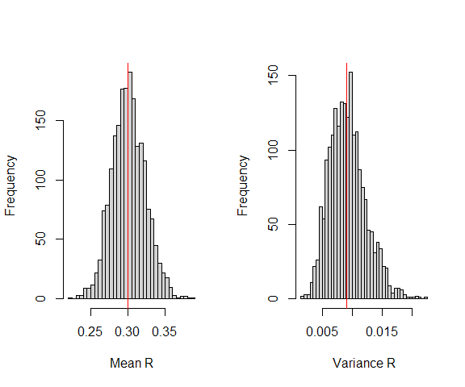

```r
## Distribution of 2000 samples
bs <- replicate(n=2000, expr=unlist(x=prBootstrap(prRec=prRecruitsG, ps=ps, n=17, Msf=Msf)))
opar <- par(mfrow=c(1,2))
hist(x=bs[1,], breaks=50, xlab="Mean R", main="")
abline(v=median(x=bs[1,]), col="red")
hist(x=bs[2,], breaks=50, xlab="Variance R", main="")
abline(v=median(x=bs[2,]), col="red")
par(opar)
```

#### Log Normal

Generate model parameters from the observed mean and variance of R assuming the log Normal model

```r
## Compute model parameters that give mean R = 0.3 and var R = 0.01,
## when R is the proportion of recruits in the population
ps <- prRecruitParsLN(mnR=0.3, vrR=0.01, Msf=Msf)
```

Simulate a new values for the mean and variance on which subsequent projections could be based, assuming the original estimates were generated from 17 independent survey

```r
## Simulate new mean and variance for 17 surveys
prBootstrap(prRec=prRecruitsLN, ps=ps, n=17, Msf=Msf)
$mnR
[1] 0.264359

$vrR
[1] 0.006793528

$p
[1] 0

$n
[1] 17

$r
[1] 1
```

Generate 2000 bootstrap samples and examine the distribution of the simulated mean and variance

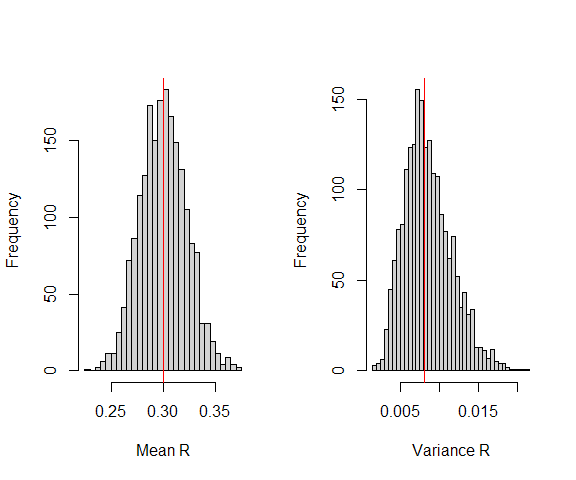

```r
## Distribution of 2000 samples
bs <- replicate(n=2000, expr=unlist(x=prBootstrap(prRec=prRecruitsLN, ps=ps, n=17, Msf=Msf)))
opar <- par(mfrow=c(1,2))
hist(x=bs[1,], breaks=50, xlab="Mean R", main="")
abline(v=median(x=bs[1,]), col="red")
hist(x=bs[2,], breaks=50, xlab="Variance R", main="")
abline(v=median(x=bs[2,]),col="red")
par(opar)
```

#### GYM

Generate model parameters from the observed mean and variance of R assuming the model implemented in the GYM

```r
## Compute model parameters that give mean R = 0.3 and var R = 0.01,
## when R is the proportion of recruits in the population
ps <- prRecruitParsGYM(mnR=0.3, vrR=0.01, Msf=Msf)
```

Simulate a new values for the mean and variance on which subsequent projections could be based, assuming the original estimates were generated from 17 independent survey

```r
## Simulate new mean and variance for 17 surveys
prBootstrap(prRec=prRecruitsGYM, ps=ps, n=17, Msf=Msf)
$mnR
[1] 0.2780201

$vrR
[1] 0.006137502

$p
[1] 0

$n
[1] 17

$r
[1] 1
```

Generate 2000 bootstrap samples and examine the distribution of the simulated mean and variance

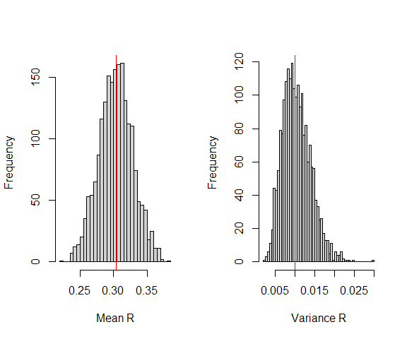

```r
## Distribution of 2000 samples
bs <- replicate(n=2000,expr=unlist(prBootstrap(prRec=prRecruitsGYM, ps=ps, n=17, Msf=Msf)))
opar <- par(mfrow=c(1,2))
hist(x=bs[1,], breaks=50, xlab="Mean R", main="")
abline(v=median(x=bs[1,]), col="red")
hist(x=bs[2,], breaks=50, xlab="Variance R", main="")
abline(v=median(x=bs[2,]), col="red")
par(opar)
```

## resampleRGYM

The `resampleRGYM` function resamples the mean and variance of $R$ using the same procedure implemented in the GYM. **This procedure is based on a false premise and should not be used**.

The variances simulated by this technique are often larger than it is possible for the variance of a proportion to be.

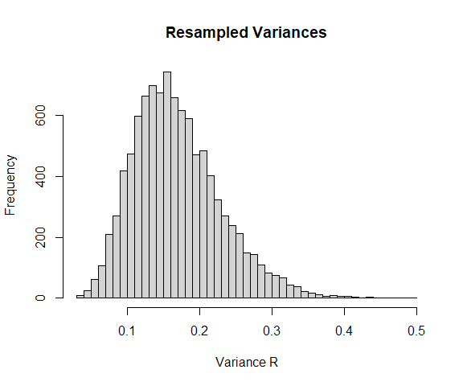

```r
## Simulate the varianceof R
vs <- replicate(n=10000, expr=resampleRGYM(mnR=0.5, vrR=0.17, n=17)$vrR)
## The simulated variance is often larger than it is possible for the
## variance of a proprtion to be
hist(x=vs, breaks=50, xlab="Variance R", main="Resampled Variances")
```

## surveySurvival

The `surveySurvival` function computes the total survival of a cohort from time of recruitment to a nominated survey period given specified natural and fishing mortalities. The resulting survivals can be used to backproject age based abundance survey data to estimate recruitment.

#### Setup

Define age classes and within year time steps

```r
## Daily time steps and 7 age classes
nsteps <- 365
Ages <- 2:8
Days <- seq(from=0, to=1, length=nsteps+1)
h <- 1/nsteps
```

Define the intra-annual natural mortality and its integral

```r
## Constant intra-annual natural mortality
ms <- matrix(data=1, nrow=nsteps+1, ncol=length(x=Ages))
ms <- ms/mean(x=trapz(fs=ms, h=h))
Ms <- ctrapz(fs=ms, h=h)
```

Suppose surveys are conducted in years 3, 4 and 5, starting on time step 190 in year 1, time step 220 in year 2 and time step 150 in year 3, and in each case the survey lasted 12 days and all age classes were surveyed.

```r
## Survey year,  period and age classes
svy <- data.frame(yr=3:5, s1=c(190, 220, 150), s2=c(201, 231, 161))
svy <- cbind(svy[rep(x=1:3, each=7), ], cls=1:7)
head(svy)
    yr  s1  s2 cls
1    3 190 201   1
1.1  3 190 201   2
1.2  3 190 201   3
1.3  3 190 201   4
1.4  3 190 201   5
1.5  3 190 201   6
```

#### Constant mortality

Assume there is no inter-annual variability in natural mortality and the annual scalings of natural mortality is constant

```r
## Constant mortality
M <- 0.2
```

The total mean survival for the cohort from the start of the year in which they were in the first age class to the survey period is

```r
## Survival to the survey period from age class 1
surveySurvival(yr=svy$yr, cls=svy$cls, s1=svy$s1, s2=svy$s2, Ms=Ms, M=M)
 [1] 0.8989089 0.7359644 0.6025567 0.4933317 0.4039058 0.3306901 0.2707462
 [8] 0.8842531 0.7239652 0.5927326 0.4852884 0.3973205 0.3252985 0.2663319
[15] 0.9188285 0.7522732 0.6159092 0.5042638 0.4128563 0.3380181 0.2767458
```

The computed survivals can be used to project cohort abundances the initial abundance for the first age class.

To compute the mean survival for the cohort from the start of the year in which they were in the third age class o the survey period

```r
## Survival to the survey period from age class 3
surveySurvival(yr=svy$yr, cls=svy$cls, s1=svy$s1, s2=svy$s2, Ms=Ms, M=M, rcls=3)
 [1] 1.3410145 1.0979298 0.8989089 0.7359644 0.6025567 0.4933317 0.4039058
 [8] 1.3191507 1.0800292 0.8842531 0.7239652 0.5927326 0.4852884 0.3973205
[15] 1.3707311 1.1222597 0.9188285 0.7522732 0.6159092 0.5042638 0.4128563
```

For age classes younger than third age class at the time of survey the surival is greater than 1.

#### Variable mortality

When there is inter-annual variability in natural mortality

```r
## Variable mortality
M <- rgamma(n=10, shape=20, rate=100)
M
 [1] 0.2548363 0.1685558 0.2044744 0.2145113 0.2621154 0.1804144 0.2283319
 [8] 0.1690220 0.1920220 0.2109510
```

the labelling of survey years (`yr`) corresponds to the elements of `M` (so `yr==1` corresponds to `M[1]`) and survival cannot be estimated for cohorts that must be projected outside the time interval spanned by `M`.

```r
## Survival cannot be projected outside the period for which mortality
## is specified.
surveySurvival(yr=svy$yr, cls=svy$cls, s1=svy$s1, s2=svy$s2, Ms=Ms, M=M)
 [1] 0.8967683 0.7576652 0.5872234        NA        NA        NA        NA
 [8] 0.8763961 0.7143291 0.6035253 0.4677582        NA        NA        NA
[15] 0.8949860 0.7221962 0.5886445 0.4973364 0.3854572        NA        NA
```

## surveyAdjustGYM

The `surveySurival` function adjusts surveyed age class abundances to initial abundances at a reference age class as implemented in the GYM. Where abundance is estimated from multiple surveys, abundance is estimated as a geometric mean of the estimates from individual surveys weighted by the inverse of the squared *coefficient of variation* of the surveyed density.

#### Survey Data

```r
#Make some survey data
survey.df <- read.csv(text="Survey, Year, Age, Density, SE, Scale, Start, End
1, 1989, 3, 0.01, 0.01, 50340.67, 178, 179
1, 1989, 4, 8.15, 8.96, 50340.67, 178, 179
1, 1989, 5, 6.58, 7.13, 50340.67, 178, 179
1, 1989, 6, 0.01, 0.01, 50340.67, 178, 179
1, 1989, 7, 0.01, 0.01, 50340.67, 178, 179
2, 1992, 3, 10.02, 8.97, 42308.13, 281, 282
2, 1992, 4, 14.12, 12.9, 42308.13, 281, 282
2, 1992, 5, 0.01, 0.01, 42308.13, 281, 282
2, 1992, 6, 15.96, 19.26, 42308.13, 281, 282
2, 1992, 7, 19.87, 21.84, 42308.13, 281, 282
3, 1998, 3, 8.72, 7.63, 81105.82, 120, 121
3, 1998, 4, 0.01, 0.01, 81105.82, 120, 121
3, 1998, 5, 73.32, 65.51, 81105.82, 120, 121
3, 1998, 6, 94.41, 104.99, 81105.82, 120, 121
3, 1998, 7, 0.01, 0.01, 81105.82, 120, 121
3, 1998, 8, 36.55, 31.68, 81105.82, 120, 121
4, 2000, 3, 7.04, 8.31, 84767.1, 175, 176
4, 2000, 4, 12.6, 15.56, 84767.1, 175, 176
4, 2000, 5, 30.79, 35.74, 84767.1, 175, 176
4, 2000, 6, 56.52, 47.78, 84767.1, 175, 176
4, 2000, 7, 27.55, 30.16, 84767.1, 175, 176
5, 2001, 3, 10.51, 9.37, 86130.6, 175, 176
5, 2001, 4, 14.51, 17.19, 86130.6, 175, 176
5, 2001, 5, 0.01, 0.01, 86130.6, 175, 176
5, 2001, 6, 37.78, 42.56, 86130.6, 175, 176
5, 2001, 7, 30.29, 37.05, 86130.6, 175, 176
6, 2002, 3, 8.59, 10.36, 42865.61, 153, 154
6, 2002, 4, 24.15, 23.4, 42865.61, 153, 154
6, 2002, 5, 35.82, 30.15, 42865.61, 153, 154
6, 2002, 6, 24.58, 21.35, 42865.61, 153, 154
7, 2003, 3, 0.01, 0.01, 86229.58, 156, 157
7, 2003, 4, 25.4, 28.86, 86229.58, 156, 157
7, 2003, 5, 68.98, 66, 86229.58, 156, 157
7, 2003, 6, 59.71, 74.47, 86229.58, 156, 157
8, 2004, 3, 0.01, 0.01, 85208.41, 156, 157
8, 2004, 4, 0.01, 0.01, 85208.41, 156, 157
8, 2004, 5, 28.67, 29.37, 85208.41, 156, 157
8, 2004, 6, 24.2, 29.24, 85208.41, 156, 157
9, 2005, 3, 0.01, 0.01, 84305.83, 171, 172
9, 2005, 4, 11.77, 11.17, 84305.83, 171, 172
9, 2005, 5, 0.01, 0.01, 84305.83, 171, 172
9, 2005, 6, 19.68, 18.49, 84305.83, 171, 172", header=TRUE)
```

#### Setup

Define age classes and within year time steps

```r
## Daily time steps and 7 age classes
nsteps <- 365
Ages <- 2:8
Days <- seq(from=0, to=1, length=nsteps+1)
h <- 1/nsteps
```

Define the intra-annual natural mortality and its integral

```r
## Constant intra-annual natural mortality
ms <- matrix(data=1, nrow=nsteps+1, ncol=length(Ages))
ms <- ms/mean(x=trapz(fs=ms, h=h))
Ms <- ctrapz(fs=ms, h=h)
```

Suppose surveys are conducted in years 3, 4 and 5, starting on time step 190 in year 1, time step 220 in year 2 and time step 150 in year 3, and in each case the survey lasted 12 days and all age classes were surveyed.

```r
## Survey year,  period and age classes
svy <- data.frame(yr=3:5, s1=c(190, 220, 150), s2=c(201, 231, 161))
svy <- cbind(svy[rep(1:3, each=7), ], cls=1:7)
head(svy)
    yr  s1  s2 cls
1    3 190 201   1
1.1  3 190 201   2
1.2  3 190 201   3
1.3  3 190 201   4
1.4  3 190 201   5
1.5  3 190 201   6
```

#### Constant mortality

Assume there is no inter-annual variability in natural mortality and the annual scalings of natural mortality is constant

```r
## Constant mortality
M <- 0.2
```

Convert surveyed age to the modelled age class

```r
## Convert age to age class
survey.df$AgeClass <- survey.df$Age-min(Ages)+1
```

Estimate the abundance of the first age class

```r
## Adjust survey abundances to abundance of reference age class
surveyAdjustGYM(survey.df=survey.df, Ms=Ms, M=M, rcls=1)
     Year       RAbund
1984 1984 1.508180e+03
1985 1985 1.234793e+03
1986 1986 6.652137e+05
1987 1987 1.340961e+06
1988 1988 1.660966e+04
1989 1989 8.989819e+02
1990 1990 1.039266e+06
1991 1991 6.038108e+05
1992 1992 1.050824e+07
1993 1993 2.353877e+03
1994 1994 1.819462e+07
1995 1995 9.455491e+06
1996 1996 5.501951e+05
1997 1997 2.644355e+06
1998 1998 2.030516e+05
1999 1999 2.766914e+06
2000 2000 3.067984e+06
2001 2001 2.743771e+06
2002 2002 1.388601e+03
2003 2003 5.189675e+04
2004 2004 1.130551e+03
```

#### Variable mortality

When there is inter-annual variability in natural mortality

```r
## Variable mortality (22 years between 0.2 & 0.201)
M <- runif(n=22, min=0.2, max=0.201)
```

The labelling of survey years (`Year`) must corresponds to the elements of `M` (so `Year==1` corresponds to `M[1]`)

```r
## M[1] must correspond to Year==1
survey.df$Year0 <- survey.df$Year
survey.df$Year <- survey.df$Year0-1983
```

Estimate the abundance of the first age class

```r
## Adjust survey abundances to abundance of reference age class
rec.df <- surveyAdjustGYM(survey.df=survey.df, Ms=Ms, M=M, rcls=1)
rec.df$Year <- rec.df$Year+1983
rec.df
   Year       RAbund
1  1984 1.511734e+03
2  1985 1.236769e+03
3  1986 6.662517e+05
4  1987 1.342796e+06
5  1988 1.662574e+04
6  1989 9.002143e+02
7  1990 1.040243e+06
8  1991 6.041088e+05
9  1992 1.052879e+07
10 1993 2.358396e+03
11 1994 1.822611e+07
12 1995 9.472546e+06
13 1996 5.513901e+05
14 1997 2.649124e+06
15 1998 2.034827e+05
16 1999 2.771214e+06
17 2000 3.072336e+06
18 2001 2.749895e+06
19 2002 1.390663e+03
20 2003 5.193408e+04
21 2004 1.131577e+03
```

Abundance cannot be estimated for cohorts that must be projected outside the time interval spanned by `M`

```r
survey.df$Year <- survey.df$Year0-1985
## Adjust survey abundances to abundance of reference age class
rec.df <- surveyAdjustGYM(survey.df=survey.df, Ms=Ms, M=M, rcls=1)
rec.df$Year <- rec.df$Year+1985
rec.df
   Year       RAbund
-1 1984           NA
0  1985           NA
1  1986 6.663512e+05
2  1987 1.343052e+06
3  1988 1.663304e+04
4  1989 9.001976e+02
5  1990 1.040367e+06
6  1991 6.042780e+05
7  1992 1.052527e+07
8  1993 2.356640e+03
9  1994 1.820749e+07
10 1995 9.467024e+06
11 1996 5.510512e+05
12 1997 2.647116e+06
13 1998 2.034813e+05
14 1999 2.772440e+06
15 2000 3.072939e+06
16 2001 2.748264e+06
17 2002 1.390364e+03
18 2003 5.198308e+04
19 2004 1.131752e+03
```